# Term Project Report

Osman Oguz Nuhoglu, Beste Yildiz Yilmaz, Efe Ahmet Guden - IE360 - Spring 2021

## Introduction

Forecasting the future sales is an important issue in e-commerce. Accurate forecasts help firms to keep appropriate levels of inventory. If forecasts are inaccurate, the firm may face high inventory levels or stock outs. This will lead to carrying costs or lost sales. Another benefit of accurate forecasts is predicting the future revenues of the firms. This may help firms to better adjust their financial situations. In this project, number of sales of several products which are sold on [Trendyol](https://www.trendyol.com/) are tried to be forecasted with several time series forecasting methods.

## Related Literature

In Spring 2020, Ekin Karamalak, Elif Bayazit, Anil Baran Dogan, Yusuf Ozdemir, Esranur Tinaz (Group 11) considered day of the week for building linear models for the same project. Their approach is used in this study as well. In addition to this, several theoretical concepts are studied from [Time Series Analysis and Its Applications With R Examples - 4th Edition - Shumway, Stoffer](https://www.stat.pitt.edu/stoffer/tsa4/tsa4.pdf).

## Data Manipulation

```r
data1[,price:=round(price,2)]
data1[,event_date:=as.Date(event_date, format = "%d/%m/%Y")]
data1 = data1[order(event_date, decreasing = FALSE)]

data2 = data2[event_date<"2021-06-10"]
data2[,c("ty_visits", "category_basket", "category_favored"):=NULL]
data = rbind(data1, data2, fill = TRUE)
```

## Methodology

There are many variables which can be used to create a model. But some of those variables cannot be used due to several reasons. Before getting them, it may be better to explain why a model should contain those variables. In other words, what should be caught in these series? Well, a typical time series contains seasonality effect which is not the case now but discussed in more detail later. Other than that, a typical time series contains trend-cycle component which can be easily modeled by differencing the series. Remaining part of the series is so-called random component, but typically it may depend on some variables. This is where the external variables enter the equation. Note that the time series decomposition is not used in this study, nevertheless it is important to understand the characteristics of a time series.

Available external variables are `price`, `visit_count`, `favored_count`, `basket_count`, `category_sold`, `category_brand_sold`, `category_visits`. Two variables are added along with those. One of them is `wday` indicating the day of the week, and the other is `special` indicating whether a day is a special day such as Black Friday or not.

For example, there was a special discounts for most of the products between 2020-11-25 and 2020-11-29 due to Black Friday.

```r
data[, wday:=wday(event_date)]


specialdays=c(seq(as.Date("2020-11-09"),as.Date("2020-11-10"),by=1), #9-11 kasım indirimi
              seq(as.Date("2020-11-25"),as.Date("2020-11-29"),by=1), #black friday
              seq(as.Date("2020-06-18"),as.Date("2020-06-20"),by=1), #haziran en uzun gün fırsatları
              seq(as.Date("2020-09-10"),as.Date("2020-09-12"),by=1), #mega eylül
              seq(as.Date("2020-10-06"),as.Date("2020-10-08"),by=1), #büyük ekim
              seq(as.Date("2020-12-21"),as.Date("2020-12-23"),by=1))
data[,special:=0]
for(i in specialdays){
  data[event_date==i,special:=1]
}
```

Other than the special days and discounts, demand may be assumed as a random process. Since a variable indicating special days is available, it is now important to detect a discount for a specific product.

Among those variables `price` cannot be used because it is not randomly determined and cannot be forecasted. Use of lagged variable cannot be used either, because the price of the previous days most probably does not affect the sales today. `visit_count`, `favored_count`, `category_sold`, `category_brand_sold`, and `category_visits` are not reliable because some of them are only available for a specific time period and others are not stable over time. There are only `basket_count`, `wday`, and `special` left. Those three variables will be used for each product. Lagged `basket_count` will be used instead of `basket_count` because if lagged variables will not be used, then they have to be forecasted. But this arises the same problem. The data cannot be modeled properly, because the discount times for specific products are unknown. Lagged `basket_count` variable can be used for this purpose since people add the items to the basket when they know there will be a discount the next day. Even if they do not know, if they add the item to their basket and do not buy it yet, they can be buy it when there is a discount.

For each product, three models will be compared and the best model will be used to make a forecast. First model will be an ARIMA model fitted to differenced and log transformed `sold_count`. The second model is simply an ARIMAX model, but implemented in a different way because of an error throwed by `forecast()` function. An ARIMA model will be fit to the residuals of a linear model fitted to differenced and log transformed `sold_count`. And the last model is an ARIMA model which is fitted to the differenced residuals of a linear model fitted to `sold_count`.

Since ARIMAX models are implemented in a different way, making forecasts may be hard to understand. The detailed explanation can be found in Appendix.

We deal with products separately. Also we define a 2x9 matrix in order to keep the forecasted values and IDs of the products.

```r
data_1 = data[product_content_id==48740784] #coat
data_2 = data[product_content_id==73318567] #bikini top 1
data_3 = data[product_content_id==32737302] #bikini top 2
data_4 = data[product_content_id==31515569] #tight
data_5 = data[product_content_id==6676673]  #headphones
data_6 = data[product_content_id==7061886]  #vacuum cleaner
data_7 = data[product_content_id==85004]    #face cleanser
data_8 = data[product_content_id==4066298]  #baby wipe
data_9 = data[product_content_id==32939029] #electric toothbrush

fcst = matrix(nrow=2,ncol=9)
fcst[2,1]=48740784
fcst[2,2]=73318567
fcst[2,3]=32737302
fcst[2,4]=31515569
fcst[2,5]=6676673
fcst[2,6]=7061886
fcst[2,7]=85004
fcst[2,8]=4066298
fcst[2,9]=32939029
```

## Function Definitions

Throughout the study, we will be using two functions. We define them here. Note that these functions are from the lectures. The first one is to build models and make forecasts conveniently. The second one is for comparing different models.

```r
forecast_with_arima=function(data,forecast_ahead,target_name='sold_count',
                             is_seasonal=F,is_stepwise=F,is_trace=T,is_approx=F){
  command_string=sprintf('input_series=data$%s',target_name)
  eval(parse(text=command_string))

  fitted=auto.arima(input_series,seasonal=is_seasonal,
                    trace=is_trace,stepwise=is_stepwise,approximation=is_approx)

  forecasted=forecast(fitted,h=forecast_ahead)
  return(list(forecast=as.numeric(forecasted$mean),model=fitted))
}

accu=function(actual,forecast){
  n=length(actual)
  error=actual-forecast
  mean=mean(actual)
  sd=sd(actual)
  CV=sd/mean
  FBias=sum(error)/sum(actual)
  MAPE=sum(abs(error/actual))/n
  RMSE=sqrt(sum(error^2)/n)
  MAD=sum(abs(error))/n
  MADP=sum(abs(error))/sum(abs(actual))
  WMAPE=MAD/mean
  l=data.frame(n,mean,sd,CV,FBias,MAPE,RMSE,MAD,MADP,WMAPE)
  return(l)
}
```

## Building Models

### Product 1

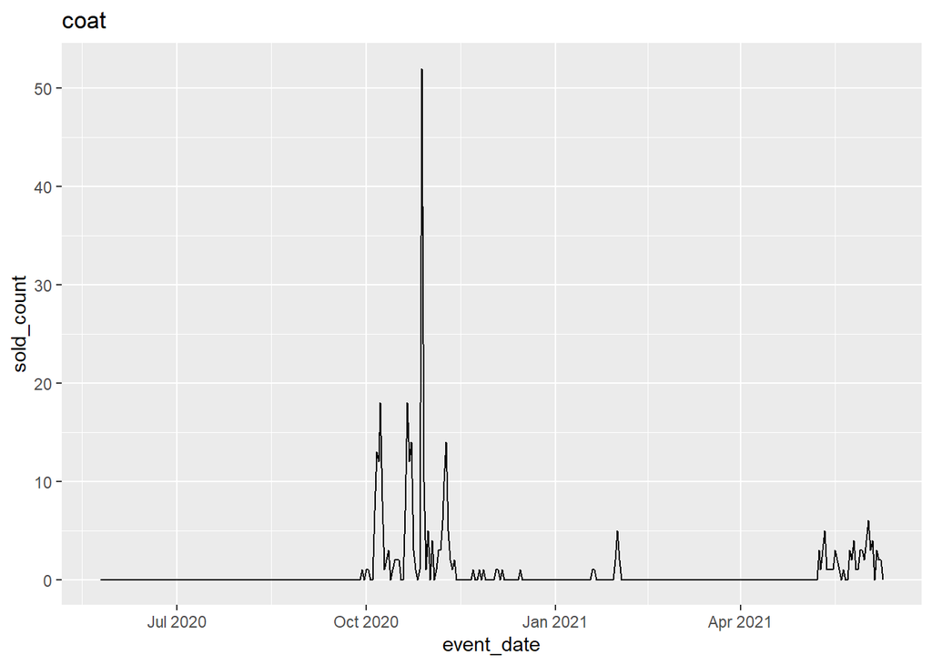

```r
ggplot(data_1, aes(x=event_date, y=sold_count)) + geom_line() + labs(title = "coat")
```

There were probably some stockout problems. Note that this product can be highly affected by seasons. There is no need to use the data between Oct 2020 and Nov 2020 because that period represents another season.

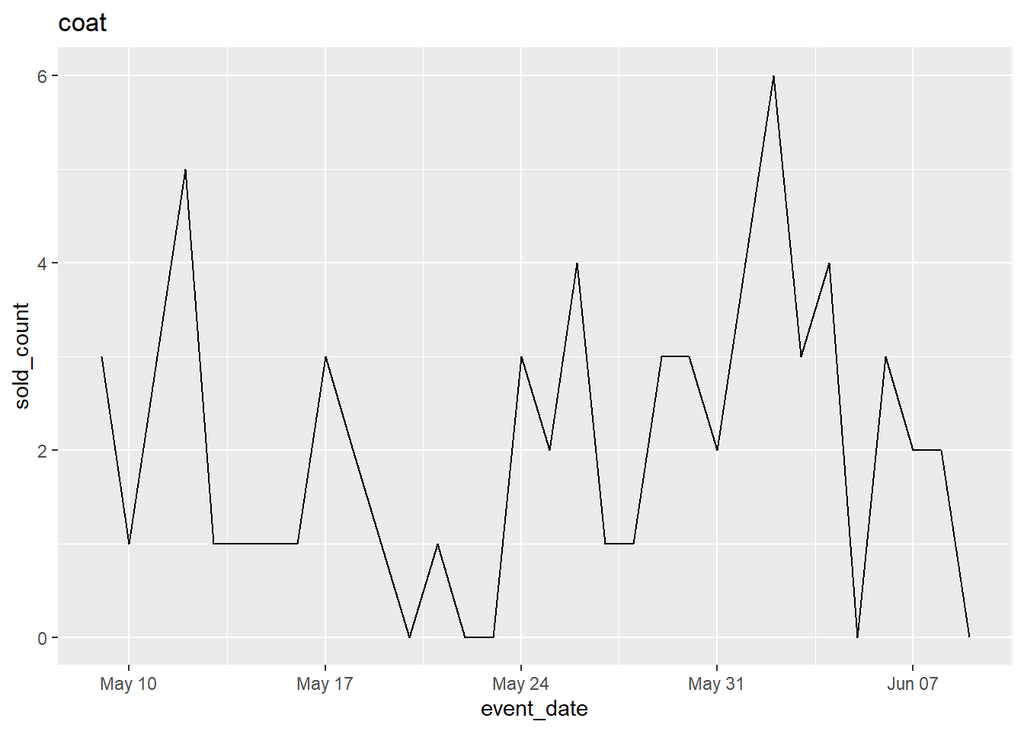

```r
data_1 = data_1[event_date>="2021-05-09"]
ggplot(data_1, aes(x=event_date, y=sold_count)) + geom_line() + labs(title = "coat")
```

Now the data is very limited. There is no need to transform the series.

```r
summary(ur.kpss(data_1[,sold_count]))
```

```
##
## #######################
## # KPSS Unit Root Test #
## #######################
##
## Test is of type: mu with 3 lags.
##
## Value of test-statistic is: 0.1488
##
## Critical value for a significance level of:
##                 10pct  5pct 2.5pct  1pct
## critical values 0.347 0.463  0.574 0.739
```

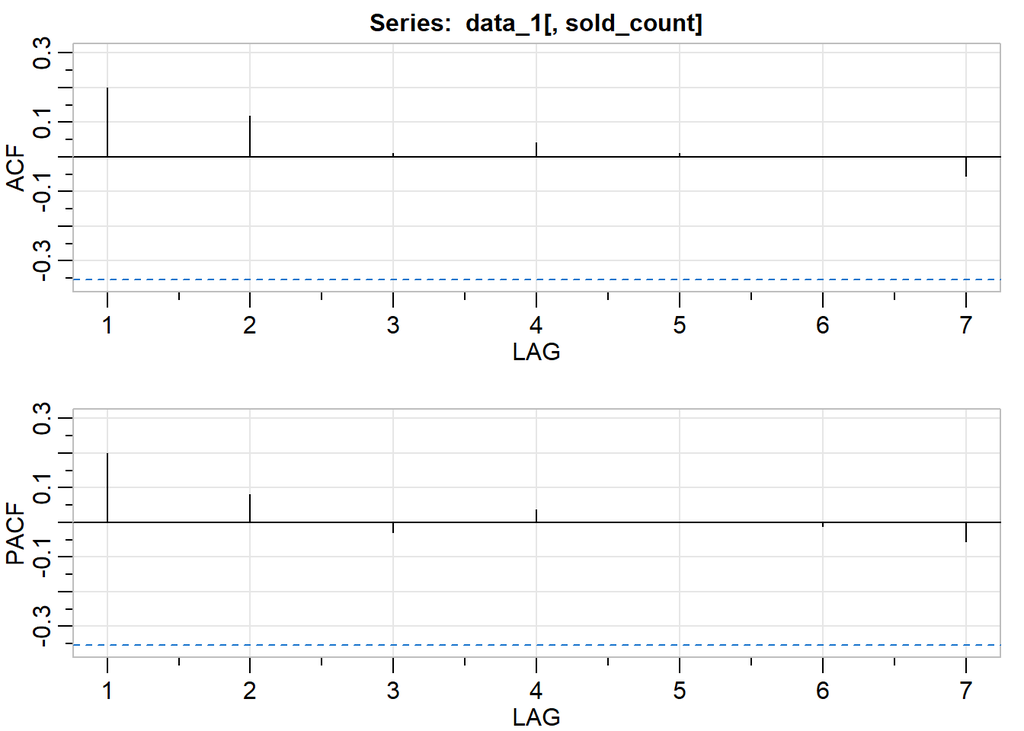

```
##      [,1] [,2]  [,3] [,4] [,5]  [,6]  [,7]
## ACF   0.2 0.12  0.01 0.04 0.01  0.00 -0.06
## PACF  0.2 0.08 -0.03 0.04 0.00 -0.01 -0.06
```

```r
acf2(data_1[,sold_count])
```

Unit root test suggests that the time series is stationary and both ACF and PACF suggest that there is not dependency.

```r
data_1[,lag2_basket_count:=shift(basket_count,2)]
lm_1 = lm(sold_count~lag2_basket_count+special+as.factor(wday), data_1)
anova(lm_1)
```

```
## Analysis of Variance Table
##
## Response: sold_count
##                   Df Sum Sq Mean Sq F value Pr(>F)
## lag2_basket_count  1  3.257  3.2570  1.3409 0.2593
## as.factor(wday)    6 15.173  2.5288  1.0411 0.4261
## Residuals         22 53.437  2.4290
```

There is no important relationship between the time series and variables.

As ACF and PACF suggest, the time series is random. Therefore, it is not an ARIMA process. It looks like white noise series.

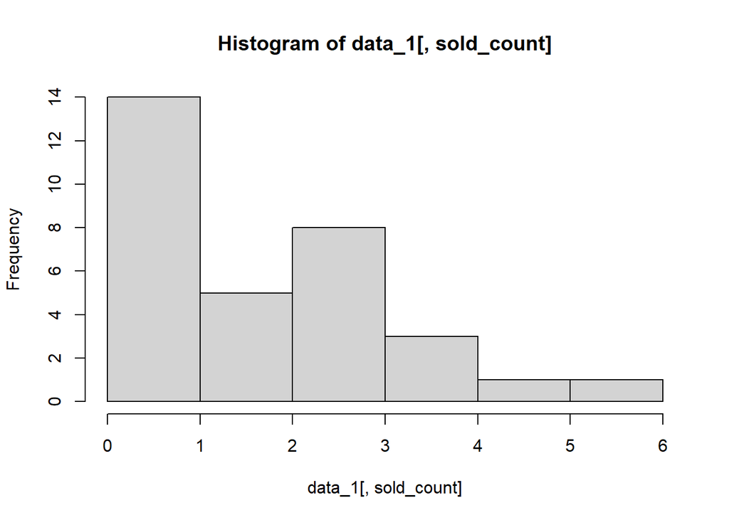

```r
hist(data_1[,sold_count])
```

Above histogram suggests that this is not a Gaussian white noise. In order to make a forecast, the median of the time series can be used.

```r
fcst[1,1]=median(data_1[,sold_count])
```

### Product 2

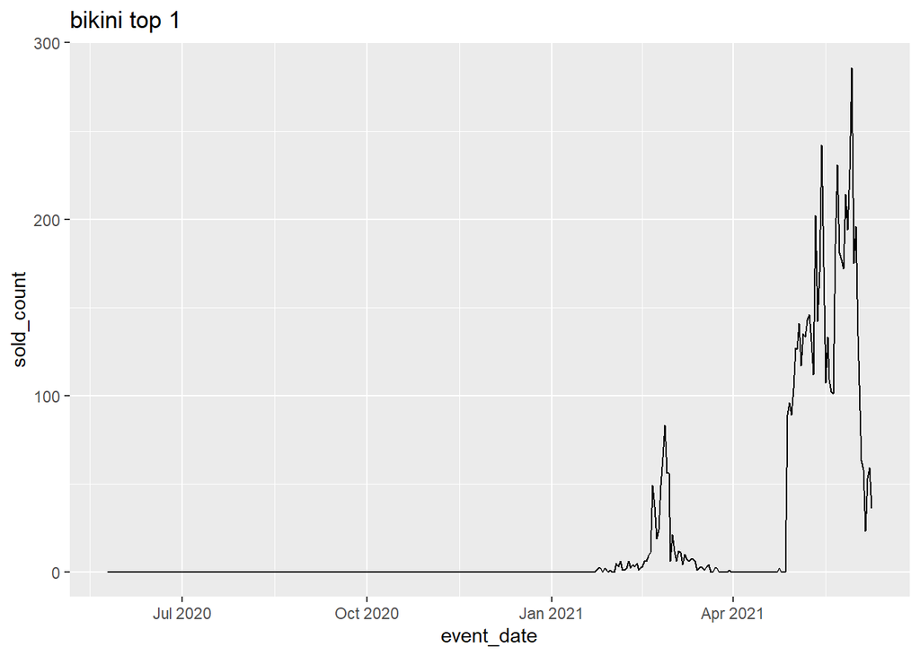

```r
ggplot(data_2, aes(x=event_date, y=sold_count)) + geom_line() + labs(title = "bikini top 1")
```

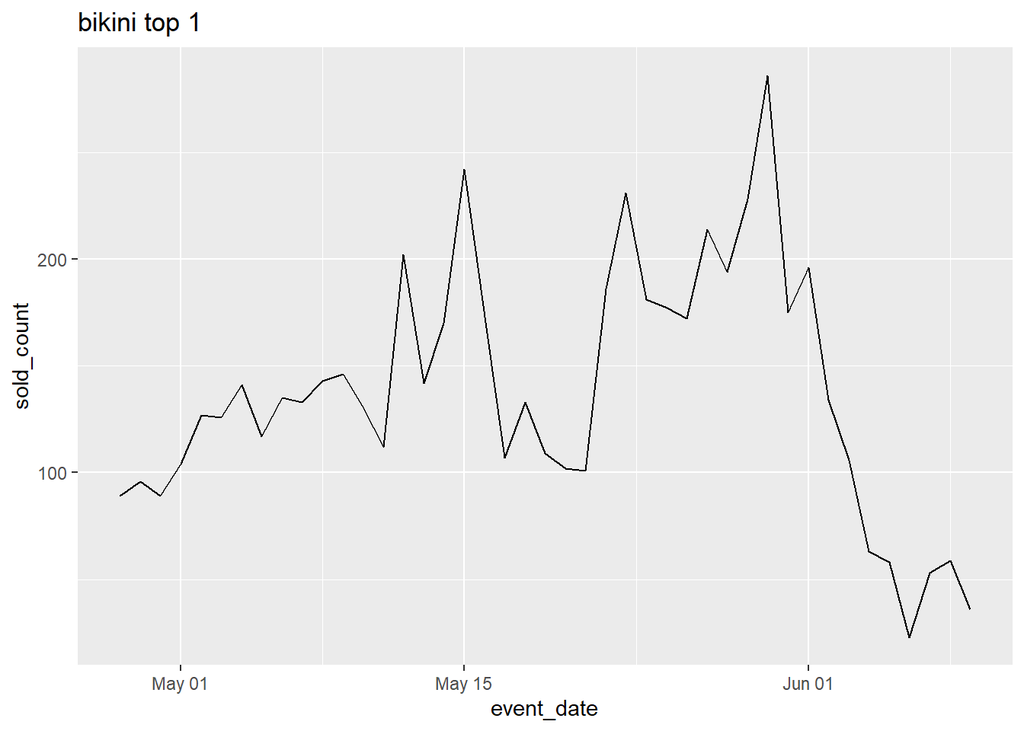

```r
data_2 = data_2[event_date>="2021-04-28"]
ggplot(data_2, aes(x=event_date, y=sold_count)) + geom_line() + labs(title = "bikini top 1")
```

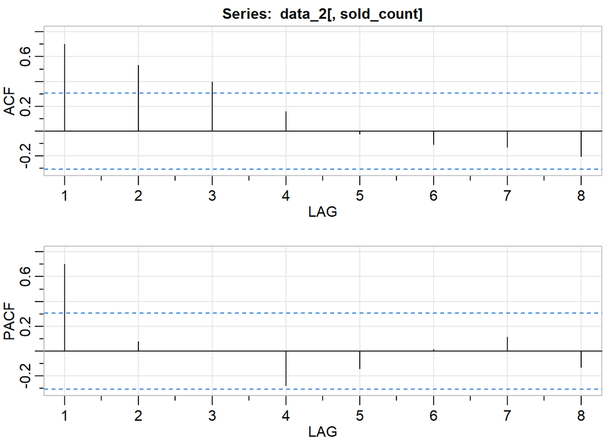

```
##      [,1] [,2] [,3]  [,4]  [,5]  [,6]  [,7]  [,8]
## ACF   0.7 0.53  0.4  0.16 -0.02 -0.11 -0.13 -0.20
## PACF  0.7 0.08  0.0 -0.28 -0.14  0.01  0.11 -0.13
```

```r
acf2(data_2[,sold_count])
```

According to ACF and PACF, there is not seasonality effect. Since there are not many observations, Box-Cox transformation is not essential. It can be skipped.

```r
summary(ur.kpss(data_2[,sold_count]))
```

```
##
## #######################
## # KPSS Unit Root Test #
## #######################
##
## Test is of type: mu with 3 lags.
##
## Value of test-statistic is: 0.1665
##
## Critical value for a significance level of:
##                 10pct  5pct 2.5pct  1pct
## critical values 0.347 0.463  0.574 0.739
```

Unit root test suggests that the time series is stationary. Recalling ACF and PACF, the time series looks like a typical AR(1) process.

At this point, a linear model can be fitted to the time series.

```r
data_2[,lag2_basket_count:=shift(basket_count,2)]
lm_2 = lm(sold_count~lag2_basket_count+special+as.factor(wday), data_2)
anova(lm_2)
```

```
## Analysis of Variance Table
##
## Response: sold_count
##                   Df Sum Sq Mean Sq F value    Pr(>F)
## lag2_basket_count  1  37269   37269 16.6121 0.0002712 ***
## as.factor(wday)    6  24535    4089  1.8227 0.1249269
## Residuals         33  74034    2243
## ---
## Signif. codes:  0 '***' 0.001 '**' 0.01 '*' 0.05 '.' 0.1 ' ' 1
```

Note that `special` variable is not shown in the `anova()` table because it is all zero after 2021-02-20. The only important variable is `lag2_basket_count`.

```r
lm_2 = lm(sold_count~lag2_basket_count, data_2)
summary(lm_2)
```

```
##
## Call:
## lm(formula = sold_count ~ lag2_basket_count, data = data_2)
##
## Residuals:
##     Min      1Q  Median      3Q     Max
## -86.373 -27.640  -5.245  17.693 125.532
##
## Coefficients:
##                   Estimate Std. Error t value Pr(>|t|)
## (Intercept)       72.40638   19.37273   3.738 0.000595 ***
## lag2_basket_count  0.10623    0.02766   3.840 0.000440 ***
## ---
## Signif. codes:  0 '***' 0.001 '**' 0.01 '*' 0.05 '.' 0.1 ' ' 1
##
## Residual standard error: 50.27 on 39 degrees of freedom
##   (2 observations deleted due to missingness)
## Multiple R-squared:  0.2744, Adjusted R-squared:  0.2558
## F-statistic: 14.75 on 1 and 39 DF,  p-value: 0.0004404
```

```r
data_2[,res:=c(rep(NA,2),residuals(lm_2))]
summary(ur.kpss(data_2[,res]))
```

```
##
## #######################
## # KPSS Unit Root Test #
## #######################
##
## Test is of type: mu with 3 lags.
##
## Value of test-statistic is: 0.2288
##
## Critical value for a significance level of:
##                 10pct  5pct 2.5pct  1pct
## critical values 0.347 0.463  0.574 0.739
```

Test-statistic is small enough, thus differencing is not needed.

At this point, two models will be compared. We also define test periods in the following chunk. This algorithm is for comparing different models and is from the lectures.

```r
forecast_ahead=2
train_start=as.Date('2020-05-25')
test_start=as.Date('2021-05-20')
test_end=as.Date('2021-06-09')
test_dates=seq(test_start,test_end,by='day')
```

```r
results=vector('list',length(test_dates))
for(i in 1:length(test_dates)){
  current_date=test_dates[i]-forecast_ahead

  past_data=data_2[event_date<=current_date]
  forecast_data=data_2[event_date==test_dates[i]]

  # arima model
  frcst=forecast_with_arima(past_data, forecast_ahead, target_name = "sold_count", is_trace = F)
  forecast_data[,arima_prediction:=round(frcst$forecast[2],
                                         0)]

  # arimax model (not exactly arimax)
  frcst=forecast_with_arima(past_data, forecast_ahead, target_name = "res", is_trace = F)
  reg = data.frame(lag2_basket_count=past_data[.N,lag2_basket_count])
  forecast_data[,arimax_prediction:=round(frcst$forecast[2]+
                                          predict(lm_2,reg),
                                          0)]
  results[[i]]=forecast_data
}
overall_results=rbindlist(results)
melted_result_2=melt(overall_results,c('event_date','sold_count'),
                     c('arima_prediction','arimax_prediction'))
performance_2= melted_result_2[,accu(sold_count,value),by=list(variable)]
performance_2
```

```
##             variable  n     mean       sd        CV       FBias      MAPE
## 1:  arima_prediction 21 141.6667 74.72304 0.5274568 -0.07394958 0.6345967
## 2: arimax_prediction 21 141.6667 74.72304 0.5274568 -0.06991597 0.8293314
##        RMSE      MAD      MADP     WMAPE
## 1: 64.92707 59.04762 0.4168067 0.4168067
## 2: 77.72540 66.47619 0.4692437 0.4692437
```

The first model is better and it will be used to make forecasts.

```r
model_2=forecast_with_arima(data_2,forecast_ahead = 2, target_name = "sold_count")
```

```
##
##  ARIMA(0,0,0) with zero mean     : 554.7663
##  ARIMA(0,0,0) with non-zero mean : 474.195
##  ARIMA(0,0,1) with zero mean     : 514.7922
##  ARIMA(0,0,1) with non-zero mean : 456.0865
##  ARIMA(0,0,2) with zero mean     : 495.8984
##  ARIMA(0,0,2) with non-zero mean : 454.0833
##  ARIMA(0,0,3) with zero mean     : 486.6369
##  ARIMA(0,0,3) with non-zero mean : 446.9203
##  ARIMA(0,0,4) with zero mean     : Inf
##  ARIMA(0,0,4) with non-zero mean : 445.2757
##  ARIMA(0,0,5) with zero mean     : Inf
##  ARIMA(0,0,5) with non-zero mean : 447.9125
##  ARIMA(1,0,0) with zero mean     : 446.9341
##  ARIMA(1,0,0) with non-zero mean : 443.8105
##  ARIMA(1,0,1) with zero mean     : 447.1735
##  ARIMA(1,0,1) with non-zero mean : 445.7389
##  ARIMA(1,0,2) with zero mean     : 449.5999
##  ARIMA(1,0,2) with non-zero mean : 448.2454
##  ARIMA(1,0,3) with zero mean     : 451.3232
##  ARIMA(1,0,3) with non-zero mean : 445.5437
##  ARIMA(1,0,4) with zero mean     : 451.6198
##  ARIMA(1,0,4) with non-zero mean : 447.8693
##  ARIMA(2,0,0) with zero mean     : 447.4699
##  ARIMA(2,0,0) with non-zero mean : 445.75
##  ARIMA(2,0,1) with zero mean     : 449.607
##  ARIMA(2,0,1) with non-zero mean : 448.2976
##  ARIMA(2,0,2) with zero mean     : 451.8544
##  ARIMA(2,0,2) with non-zero mean : 450.7974
##  ARIMA(2,0,3) with zero mean     : 453.6656
##  ARIMA(2,0,3) with non-zero mean : 448.1174
##  ARIMA(3,0,0) with zero mean     : 449.202
##  ARIMA(3,0,0) with non-zero mean : 448.2016
##  ARIMA(3,0,1) with zero mean     : 451.388
##  ARIMA(3,0,1) with non-zero mean : 450.4475
##  ARIMA(3,0,2) with zero mean     : Inf
##  ARIMA(3,0,2) with non-zero mean : Inf
##  ARIMA(4,0,0) with zero mean     : 450.9351
##  ARIMA(4,0,0) with non-zero mean : 448.4583
##  ARIMA(4,0,1) with zero mean     : 453.6393
##  ARIMA(4,0,1) with non-zero mean : Inf
##  ARIMA(5,0,0) with zero mean     : 453.6211
##  ARIMA(5,0,0) with non-zero mean : 450.2785
##
##
##
##  Best model: ARIMA(1,0,0) with non-zero mean
```

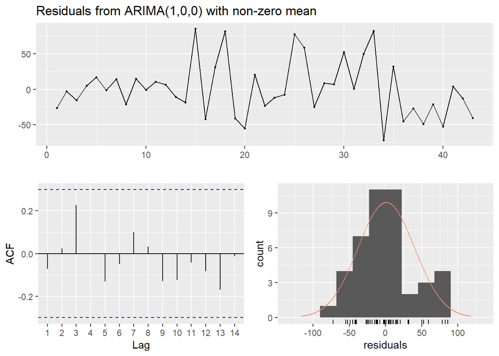

```
##
##  Ljung-Box test
##
## data:  Residuals from ARIMA(1,0,0) with non-zero mean
## Q* = 5.2821, df = 7, p-value = 0.6256
##
## Model df: 2.   Total lags used: 9
```

```r
checkresiduals(model_2$model)
```

```r
fcst[1,2] = round(model_2$forecast[2], 0)
```

Regarding the available information, the model seems to be adequate in terms of its residuals. Also note that the model fitted is AR(1).

### Product 3

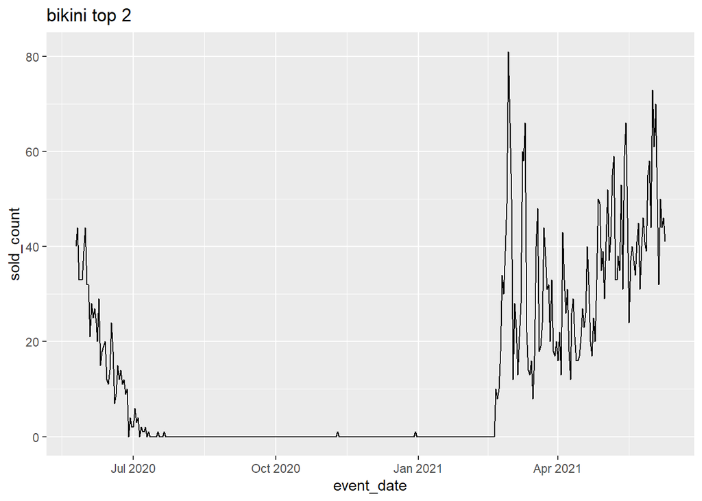

```r
ggplot(data_3, aes(x=event_date, y=sold_count)) + geom_line() + labs(title = "bikini top 2")
```

The data is not reliable until 2021-02-20, probably because of stockouts or production related problems.

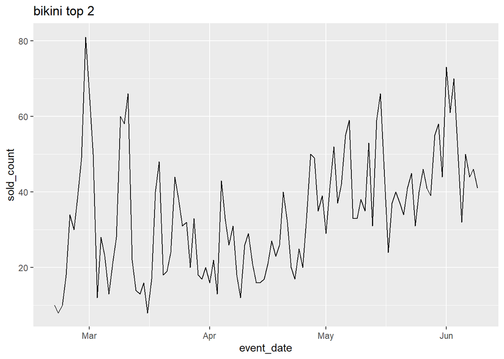

```r
data_3 = data_3[event_date>="2021-02-20"]
ggplot(data_3, aes(x=event_date, y=sold_count)) + geom_line() + labs(title = "bikini top 2")
```

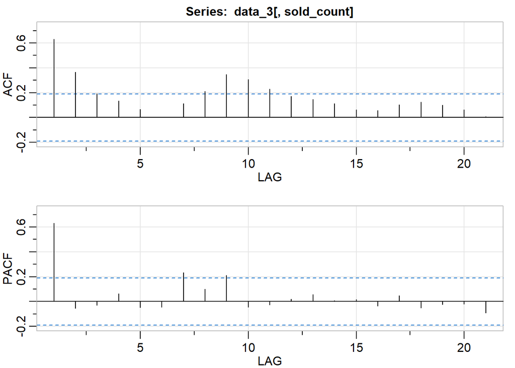

```
##      [,1]  [,2]  [,3] [,4]  [,5]  [,6] [,7] [,8] [,9] [,10] [,11] [,12] [,13]
## ACF  0.63  0.37  0.19 0.13  0.07  0.00 0.11 0.21 0.35  0.31  0.23  0.17  0.14
## PACF 0.63 -0.06 -0.03 0.06 -0.05 -0.04 0.23 0.10 0.21 -0.05 -0.03  0.02  0.06
##      [,14] [,15] [,16] [,17] [,18] [,19] [,20] [,21]
## ACF   0.11  0.06  0.06  0.10  0.12  0.10  0.06  0.01
## PACF  0.01  0.02 -0.04  0.05 -0.05 -0.02 -0.02 -0.09
```

```r
acf2(data_3[,sold_count])
```

According to ACF and PACF, there is not seasonality effect. Since there are not many observations, Box-Cox transformation is not essential. It can be skipped.

```r
summary(ur.kpss(data_3[,sold_count]))
```

```
##
## #######################
## # KPSS Unit Root Test #
## #######################
##
## Test is of type: mu with 4 lags.
##
## Value of test-statistic is: 0.815
##
## Critical value for a significance level of:
##                 10pct  5pct 2.5pct  1pct
## critical values 0.347 0.463  0.574 0.739
```

The data does not seem to be stationary as the unit root test suggests.

```r
data_3[,lag_sold_count:=shift(sold_count,1)]
data_3[,d_sold_count:=sold_count-lag_sold_count]
summary(ur.kpss(data_3[,d_sold_count]))
```

```
##
## #######################
## # KPSS Unit Root Test #
## #######################
##
## Test is of type: mu with 4 lags.
##
## Value of test-statistic is: 0.0301
##
## Critical value for a significance level of:
##                 10pct  5pct 2.5pct  1pct
## critical values 0.347 0.463  0.574 0.739
```

Now, stationarity can be assumed. At this point, a linear model can be fitted to the series. In order to use `basket_count`, it should be differenced as well. Also note the use of lagged differenced `basket_count`, since forecast for 2 periods ahead is needed.

```r
data_3[,lag_basket_count:=shift(basket_count,1)]
data_3[,diff_basket_count:=basket_count-lag_basket_count]
data_3[,lag2_basket_count:=shift(basket_count,2)]
data_3[,lag2_diff_basket_count:=shift(diff_basket_count,2)]
lm_3_1 = lm(d_sold_count~lag2_diff_basket_count+special+as.factor(wday), data_3)
anova(lm_3_1)
```

```
## Analysis of Variance Table
##
## Response: d_sold_count
##                        Df  Sum Sq Mean Sq F value Pr(>F)
## lag2_diff_basket_count  1     6.6   6.563  0.0352 0.8515
## as.factor(wday)         6  1537.1 256.192  1.3753 0.2320
## Residuals              99 18442.3 186.286
```

Note that `special` variable is not shown in the `anova()` table because it is all zero after 2021-02-20.

None of the variables is important.

So far, a linear model is tried to be fitted to differenced series. Now, as another modeling strategy, the original series is tried to be modeled linearly.

```r
lm_3_2 = lm(sold_count~as.factor(wday)+lag2_basket_count, data_3)
anova(lm_3_2)
```

```
## Analysis of Variance Table
##
## Response: sold_count
##                    Df  Sum Sq Mean Sq F value    Pr(>F)
## as.factor(wday)     6   652.9   108.8  0.5437    0.7738
## lag2_basket_count   1  6049.1  6049.1 30.2197 2.959e-07 ***
## Residuals         100 20017.0   200.2
## ---
## Signif. codes:  0 '***' 0.001 '**' 0.01 '*' 0.05 '.' 0.1 ' ' 1
```

If only the important variable is used,

```r
lm_3_2 = lm(sold_count~lag2_basket_count, data_3)
summary(lm_3_2)
```

```
##
## Call:
## lm(formula = sold_count ~ lag2_basket_count, data = data_3)
##
## Residuals:
##     Min      1Q  Median      3Q     Max
## -42.987 -10.184   0.214   8.528  34.064
##
## Coefficients:
##                   Estimate Std. Error t value Pr(>|t|)
## (Intercept)       16.70023    3.52705   4.735 6.82e-06 ***
## lag2_basket_count  0.08946    0.01609   5.561 2.03e-07 ***
## ---
## Signif. codes:  0 '***' 0.001 '**' 0.01 '*' 0.05 '.' 0.1 ' ' 1
##
## Residual standard error: 13.97 on 106 degrees of freedom
##   (2 observations deleted due to missingness)
## Multiple R-squared:  0.2258, Adjusted R-squared:  0.2185
## F-statistic: 30.92 on 1 and 106 DF,  p-value: 2.025e-07
```

```r
data_3[,res:=c(rep(NA,2),residuals(lm_3_2))]
summary(ur.kpss(data_3[,res]))
```

```
##
## #######################
## # KPSS Unit Root Test #
## #######################
##
## Test is of type: mu with 4 lags.
##
## Value of test-statistic is: 0.8754
##
## Critical value for a significance level of:
##                 10pct  5pct 2.5pct  1pct
## critical values 0.347 0.463  0.574 0.739
```

Test-statistic is large, thus differencing is needed.

```r
data_3[,lag_res:=shift(res,1)]
data_3[,d_res:=res-lag_res]
summary(ur.kpss(data_3[,d_res]))
```

```
##
## #######################
## # KPSS Unit Root Test #
## #######################
##
## Test is of type: mu with 4 lags.
##
## Value of test-statistic is: 0.0213
##
## Critical value for a significance level of:
##                 10pct  5pct 2.5pct  1pct
## critical values 0.347 0.463  0.574 0.739
```

In order to compare the models,

```r
results=vector('list',length(test_dates))
for(i in 1:length(test_dates)){
  current_date=test_dates[i]-forecast_ahead

  past_data=data_3[event_date<=current_date]
  forecast_data=data_3[event_date==test_dates[i]]

  # arima model
  frcst=forecast_with_arima(past_data, forecast_ahead, target_name = "d_sold_count", is_trace = F)
  forecast_data[,arima_prediction:=round(frcst$forecast[2]+
                                         frcst$forecast[1]+
                                         past_data[.N,c(sold_count)],
                                         0)]

  # arimax model (special)(not exactly arimax)
  frcst=forecast_with_arima(past_data, forecast_ahead, target_name = "d_res", is_trace = F)
  reg = data.frame(lag2_basket_count=past_data[.N,lag2_basket_count])
  forecast_data[,arimax_prediction:=round(frcst$forecast[2]+
                                          frcst$forecast[1]+
                                          predict(lm_3_2,reg)+
                                          past_data[.N,res],
                                          0)]

  results[[i]]=forecast_data
}
overall_results=rbindlist(results)
melted_result_3=melt(overall_results,c('event_date','sold_count'),
                     c('arima_prediction','arimax_prediction'))
performance_3= melted_result_3[,accu(sold_count,value),by=list(variable)]
performance_3
```

```
##             variable  n     mean      sd        CV      FBias      MAPE
## 1:  arima_prediction 21 46.57143 11.3911 0.2445942 0.08793456 0.1905409
## 2: arimax_prediction 21 46.57143 11.3911 0.2445942 0.10327198 0.1805079
##        RMSE      MAD      MADP     WMAPE
## 1: 12.30176 9.238095 0.1983640 0.1983640
## 2: 11.69656 8.714286 0.1871166 0.1871166
```

The second model is better.

```r
model_3=forecast_with_arima(data_3,forecast_ahead = 2, target_name = "d_res")
```

```
##
##  ARIMA(0,0,0) with zero mean     : 880.8613
##  ARIMA(0,0,0) with non-zero mean : 882.9188
##  ARIMA(0,0,1) with zero mean     : 860.7265
##  ARIMA(0,0,1) with non-zero mean : 861.5981
##  ARIMA(0,0,2) with zero mean     : 845.4656
##  ARIMA(0,0,2) with non-zero mean : Inf
##  ARIMA(0,0,3) with zero mean     : 847.4909
##  ARIMA(0,0,3) with non-zero mean : Inf
##  ARIMA(0,0,4) with zero mean     : 848.5291
##  ARIMA(0,0,4) with non-zero mean : 849.2754
##  ARIMA(0,0,5) with zero mean     : 847.0607
##  ARIMA(0,0,5) with non-zero mean : 848.2196
##  ARIMA(1,0,0) with zero mean     : 879.8116
##  ARIMA(1,0,0) with non-zero mean : 881.9062
##  ARIMA(1,0,1) with zero mean     : 850.3692
##  ARIMA(1,0,1) with non-zero mean : Inf
##  ARIMA(1,0,2) with zero mean     : 847.5307
##  ARIMA(1,0,2) with non-zero mean : Inf
##  ARIMA(1,0,3) with zero mean     : 843.6524
##  ARIMA(1,0,3) with non-zero mean : Inf
##  ARIMA(1,0,4) with zero mean     : 845.4653
##  ARIMA(1,0,4) with non-zero mean : 846.8773
##  ARIMA(2,0,0) with zero mean     : 867.7487
##  ARIMA(2,0,0) with non-zero mean : 869.8794
##  ARIMA(2,0,1) with zero mean     : 846.4843
##  ARIMA(2,0,1) with non-zero mean : 847.0805
##  ARIMA(2,0,2) with zero mean     : 848.6851
##  ARIMA(2,0,2) with non-zero mean : 849.3103
##  ARIMA(2,0,3) with zero mean     : 850.672
##  ARIMA(2,0,3) with non-zero mean : 851.263
##  ARIMA(3,0,0) with zero mean     : 864.8504
##  ARIMA(3,0,0) with non-zero mean : 867.011
##  ARIMA(3,0,1) with zero mean     : 848.6856
##  ARIMA(3,0,1) with non-zero mean : 849.3162
##  ARIMA(3,0,2) with zero mean     : 849.53
##  ARIMA(3,0,2) with non-zero mean : 850.1935
##  ARIMA(4,0,0) with zero mean     : 865.9631
##  ARIMA(4,0,0) with non-zero mean : 868.1683
##  ARIMA(4,0,1) with zero mean     : 850.581
##  ARIMA(4,0,1) with non-zero mean : 851.3313
##  ARIMA(5,0,0) with zero mean     : 867.4264
##  ARIMA(5,0,0) with non-zero mean : 869.6735
##
##
##
##  Best model: ARIMA(1,0,3) with zero mean
```

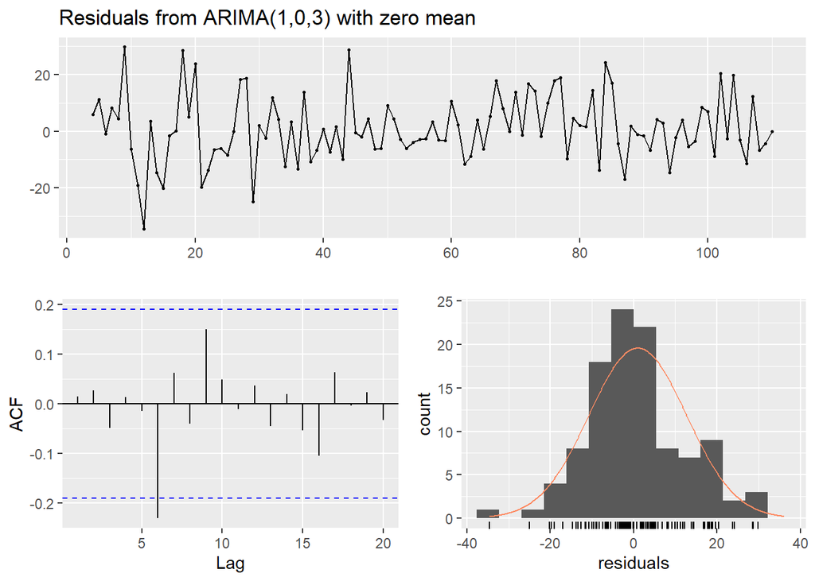

```
##
##  Ljung-Box test
##
## data:  Residuals from ARIMA(1,0,3) with zero mean
## Q* = 10.126, df = 6, p-value = 0.1194
##
## Model df: 4.   Total lags used: 10
```

```r
checkresiduals(model_3$model)
```

```r
reg = data.frame(lag2_basket_count=data_3[.N,lag2_basket_count])
fcst[1,3] = round(model_3$forecast[2]+
                  model_3$forecast[1]+
                  predict(lm_3_2,reg)+
                  data_3[.N,c(res)],
                  0)
```

Regarding the available information, the model seems to be adequate in terms of its residuals.

### Product 4

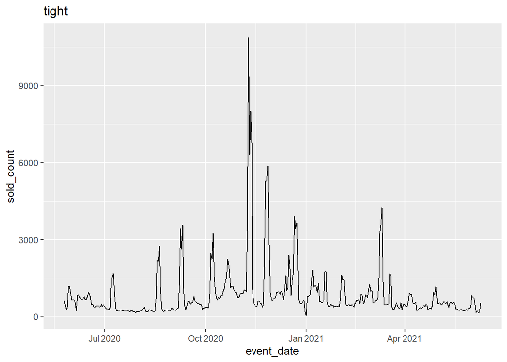

```r
ggplot(data_4, aes(x=event_date, y=sold_count)) + geom_line() + labs(title = "tight")
```

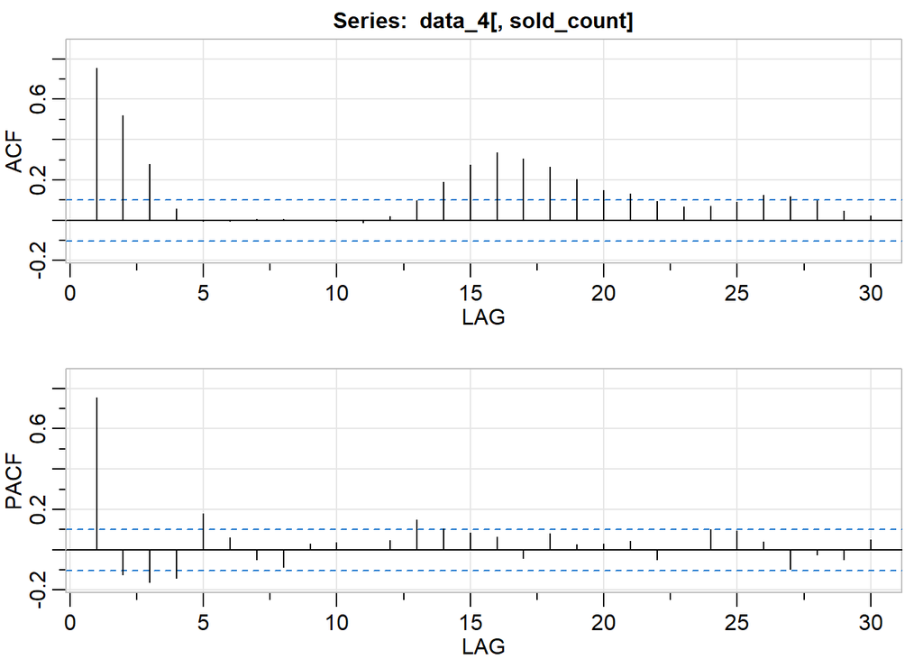

```
##      [,1]  [,2]  [,3]  [,4]  [,5]  [,6]  [,7]  [,8] [,9] [,10] [,11] [,12]
## ACF  0.76  0.52  0.28  0.06 -0.01 -0.01  0.01  0.01 0.00 -0.01 -0.01  0.02
## PACF 0.76 -0.12 -0.16 -0.14  0.18  0.06 -0.05 -0.09 0.03  0.04  0.00  0.05
##      [,13] [,14] [,15] [,16] [,17] [,18] [,19] [,20] [,21] [,22] [,23] [,24]
## ACF   0.10  0.19  0.28  0.33  0.30  0.27  0.20  0.15  0.13  0.09  0.07  0.07
## PACF  0.15  0.10  0.09  0.06 -0.04  0.08  0.03  0.03  0.04 -0.05  0.00  0.10
##      [,25] [,26] [,27] [,28] [,29] [,30]
## ACF   0.09  0.13  0.12  0.10  0.05  0.02
## PACF  0.10  0.04 -0.10 -0.02 -0.05  0.05
```

```r
acf2(data_4[,sold_count])
```

In ACF, there is a significant spike at lag 16 but this is not seasonality effect since the series is daily and lag 16 does not represent any seasonality effect. It may be transformed using Box-Cox transformation.

```r
BoxCox.lambda(data_4[,sold_count], lower=0)
```

```
## [1] 4.102259e-05
```

It is very close to zero, so a log transformation is appropriate.

```r
data_4[,log_sold_count:=log(sold_count)]
summary(ur.kpss(data_4[,log_sold_count]))
```

```
##
## #######################
## # KPSS Unit Root Test #
## #######################
##
## Test is of type: mu with 5 lags.
##
## Value of test-statistic is: 0.5865
##
## Critical value for a significance level of:
##                 10pct  5pct 2.5pct  1pct
## critical values 0.347 0.463  0.574 0.739
```

The data does not seem to be stationary as the unit root test suggests.

```r
data_4[,lag_log_sold_count:=shift(log_sold_count,1)]
data_4[,dl_sold_count:=log_sold_count-lag_log_sold_count]
summary(ur.kpss(data_4[,dl_sold_count]))
```

```
##
## #######################
## # KPSS Unit Root Test #
## #######################
##
## Test is of type: mu with 5 lags.
##
## Value of test-statistic is: 0.0098
##
## Critical value for a significance level of:
##                 10pct  5pct 2.5pct  1pct
## critical values 0.347 0.463  0.574 0.739
```

Now, stationarity can be assumed. At this point, a linear model can be fitted to the series. In order to use `basket_count`, it should be differenced as well. Also note the use of lagged differenced `basket_count`, since forecast for 2 periods ahead is needed.

```r
data_4[,lag_basket_count:=shift(basket_count,1)]
data_4[,diff_basket_count:=basket_count-lag_basket_count]
data_4[,lag2_basket_count:=shift(basket_count,2)]
data_4[,lag2_diff_basket_count:=shift(diff_basket_count,2)]
lm_4_1 = lm(dl_sold_count~lag2_diff_basket_count+special+as.factor(wday), data_4)
anova(lm_4_1)
```

```
## Analysis of Variance Table
##
## Response: dl_sold_count
##                         Df Sum Sq Mean Sq F value    Pr(>F)
## lag2_diff_basket_count   1  0.802 0.80229  4.0499    0.0449 *
## special                  1  0.029 0.02850  0.1439    0.7047
## as.factor(wday)          6  6.642 1.10699  5.5881 1.452e-05 ***
## Residuals              369 73.098 0.19810
## ---
## Signif. codes:  0 '***' 0.001 '**' 0.01 '*' 0.05 '.' 0.1 ' ' 1
```

Only `wday` variable seems to be important.

```r
lm_4_1 = lm(dl_sold_count~as.factor(wday), data_4)
summary(lm_4_1)
```

```
##
## Call:
## lm(formula = dl_sold_count ~ as.factor(wday), data = data_4)
##
## Residuals:
##      Min       1Q   Median       3Q      Max
## -1.60080 -0.17206 -0.00707  0.16972  3.15811
##
## Coefficients:
##                  Estimate Std. Error t value Pr(>|t|)
## (Intercept)       0.01049    0.06076   0.173  0.86300
## as.factor(wday)2  0.07369    0.08592   0.858  0.39161
## as.factor(wday)3  0.18865    0.08553   2.206  0.02801 *
## as.factor(wday)4  0.02798    0.08553   0.327  0.74371
## as.factor(wday)5 -0.03055    0.08592  -0.356  0.72236
## as.factor(wday)6 -0.27299    0.08592  -3.177  0.00161 **
## as.factor(wday)7 -0.06723    0.08592  -0.782  0.43446
## ---
## Signif. codes:  0 '***' 0.001 '**' 0.01 '*' 0.05 '.' 0.1 ' ' 1
##
## Residual standard error: 0.4465 on 373 degrees of freedom
##   (1 observation deleted due to missingness)
## Multiple R-squared:  0.08117,    Adjusted R-squared:  0.06639
## F-statistic: 5.492 on 6 and 373 DF,  p-value: 1.827e-05
```

```r
data_4[,res_1:=c(NA,lm_4_1$residuals)]
```

So far, a linear model is fitted to differenced and transformed series. Now, as another modeling strategy, the original series is tried to be modeled linearly.

```r
lm_4_2 = lm(sold_count~as.factor(special)+as.factor(wday)+lag2_basket_count, data_4)
anova(lm_4_2)
```

```
## Analysis of Variance Table
##
## Response: sold_count
##                     Df    Sum Sq   Mean Sq  F value  Pr(>F)
## as.factor(special)   1 121996445 121996445 175.4641 < 2e-16 ***
## as.factor(wday)      6  11030240   1838373   2.6441 0.01596 *
## lag2_basket_count    1  59859718  59859718  86.0946 < 2e-16 ***
## Residuals          370 257253159    695279
## ---
## Signif. codes:  0 '***' 0.001 '**' 0.01 '*' 0.05 '.' 0.1 ' ' 1
```

If only the important variables to be used,

```r
lm_4_2 = lm(sold_count~as.factor(special)+lag2_basket_count, data_4)
summary(lm_4_2)
```

```
##
## Call:
## lm(formula = sold_count ~ as.factor(special) + lag2_basket_count,
##     data = data_4)
##
## Residuals:
##     Min      1Q  Median      3Q     Max
## -3204.2  -225.8  -124.4    78.0  7770.5
##
## Coefficients:
##                      Estimate Std. Error t value Pr(>|t|)
## (Intercept)         3.014e+02  6.584e+01   4.577 6.41e-06 ***
## as.factor(special)1 1.911e+03  2.157e+02   8.858  < 2e-16 ***
## lag2_basket_count   1.100e-01  1.266e-02   8.692  < 2e-16 ***
## ---
## Signif. codes:  0 '***' 0.001 '**' 0.01 '*' 0.05 '.' 0.1 ' ' 1
##
## Residual standard error: 852.5 on 376 degrees of freedom
##   (2 observations deleted due to missingness)
## Multiple R-squared:  0.393,  Adjusted R-squared:  0.3898
## F-statistic: 121.7 on 2 and 376 DF,  p-value: < 2.2e-16
```

```r
data_4[,res_2:=c(rep(NA,2),residuals(lm_4_2))]
summary(ur.kpss(data_4[,res_2]))
```

```
##
## #######################
## # KPSS Unit Root Test #
## #######################
##
## Test is of type: mu with 5 lags.
##
## Value of test-statistic is: 0.2099
##
## Critical value for a significance level of:
##                 10pct  5pct 2.5pct  1pct
## critical values 0.347 0.463  0.574 0.739
```

Small test statistic suggests stationarity.

In order to compare the models,

```r
results=vector('list',length(test_dates))
for(i in 1:length(test_dates)){
  current_date=test_dates[i]-forecast_ahead

  past_data=data_4[event_date<=current_date]
  forecast_data=data_4[event_date==test_dates[i]]

  # arima model
  frcst=forecast_with_arima(past_data, forecast_ahead, target_name = "dl_sold_count", is_trace = F)
  forecast_data[,arima_prediction:=round(exp(frcst$forecast[2]+
                                             frcst$forecast[1]+
                                             past_data[.N,c(log_sold_count)]),
                                         0)]
  # arimax model (wday)(not exactly arimax)
  frcst=forecast_with_arima(past_data, forecast_ahead, target_name = "res_1", is_trace = F)
  reg1 = data.frame(wday=past_data[.N,ifelse(wday<7,wday+1,1)])
  #past_data[.N,ifelse(wday<7,wday+1,1)])
  #past_data[.N,ifelse(wday<6,wday+2,ifelse(wday==6,1,2))]
  reg2 = data.frame(wday=past_data[.N,ifelse(wday<6,wday+2,ifelse(wday==6,1,2))])
  forecast_data[,arimax_prediction_1:=round(exp(frcst$forecast[2]+
                                              frcst$forecast[1]+
                                              predict(lm_4_1,reg1)+
                                              predict(lm_4_1,reg2)+
                                              past_data[.N,c(log_sold_count)]),
                                          0)]

  # arimax model (special)(not exactly arimax)
  frcst=forecast_with_arima(past_data, forecast_ahead, target_name = "res_2", is_trace = F)
  reg = data.frame(special=as.factor(forecast_data[1,special]),lag2_basket_count=past_data[.N,lag2_basket_count])
  forecast_data[,arimax_prediction_2:=round(frcst$forecast[2]+
                                            predict(lm_4_2,reg),
                                            0)]

  results[[i]]=forecast_data
}
overall_results=rbindlist(results)
melted_result_4=melt(overall_results,c('event_date','sold_count'),
                     c('arima_prediction','arimax_prediction_1','arimax_prediction_2'))
performance_4= melted_result_4[,accu(sold_count,value),by=list(variable)]
performance_4
```

```
##               variable  n     mean       sd        CV       FBias      MAPE
## 1:    arima_prediction 21 347.0952 199.7288 0.5754294 -0.04650844 0.4520685
## 2: arimax_prediction_1 21 347.0952 199.7288 0.5754294 -0.03128001 0.3986056
## 3: arimax_prediction_2 21 347.0952 199.7288 0.5754294 -0.39827137 0.8975548
##        RMSE      MAD      MADP     WMAPE
## 1: 181.6015 136.6190 0.3936068 0.3936068
## 2: 158.5196 116.5714 0.3358485 0.3358485
## 3: 247.0077 220.1429 0.6342434 0.6342434
```

The second model is the best among these three.

```r
model_4=forecast_with_arima(data_4,forecast_ahead = 2, target_name = "res_1")
```

```
##
##  ARIMA(0,0,0) with zero mean     : 460.4642
##  ARIMA(0,0,0) with non-zero mean : 462.4854
##  ARIMA(0,0,1) with zero mean     : 453.8164
##  ARIMA(0,0,1) with non-zero mean : 455.8483
##  ARIMA(0,0,2) with zero mean     : 447.2731
##  ARIMA(0,0,2) with non-zero mean : 449.3159
##  ARIMA(0,0,3) with zero mean     : 440.5724
##  ARIMA(0,0,3) with non-zero mean : 442.6181
##  ARIMA(0,0,4) with zero mean     : 420.7241
##  ARIMA(0,0,4) with non-zero mean : 422.7773
##  ARIMA(0,0,5) with zero mean     : 402.948
##  ARIMA(0,0,5) with non-zero mean : 405.0189
##  ARIMA(1,0,0) with zero mean     : 456.2852
##  ARIMA(1,0,0) with non-zero mean : 458.3172
##  ARIMA(1,0,1) with zero mean     : 450.299
##  ARIMA(1,0,1) with non-zero mean : 452.3418
##  ARIMA(1,0,2) with zero mean     : 408.8035
##  ARIMA(1,0,2) with non-zero mean : 410.857
##  ARIMA(1,0,3) with zero mean     : 410.8567
##  ARIMA(1,0,3) with non-zero mean : 412.9212
##  ARIMA(1,0,4) with zero mean     : 406.7817
##  ARIMA(1,0,4) with non-zero mean : 408.8574
##  ARIMA(2,0,0) with zero mean     : 449.7992
##  ARIMA(2,0,0) with non-zero mean : 451.842
##  ARIMA(2,0,1) with zero mean     : 450.7144
##  ARIMA(2,0,1) with non-zero mean : 452.7683
##  ARIMA(2,0,2) with zero mean     : 408.0674
##  ARIMA(2,0,2) with non-zero mean : 410.1222
##  ARIMA(2,0,3) with zero mean     : 412.654
##  ARIMA(2,0,3) with non-zero mean : 414.7293
##  ARIMA(3,0,0) with zero mean     : 451.8186
##  ARIMA(3,0,0) with non-zero mean : 453.8723
##  ARIMA(3,0,1) with zero mean     : 410.5114
##  ARIMA(3,0,1) with non-zero mean : 412.5753
##  ARIMA(3,0,2) with zero mean     : 410.894
##  ARIMA(3,0,2) with non-zero mean : 412.9698
##  ARIMA(4,0,0) with zero mean     : 439.4205
##  ARIMA(4,0,0) with non-zero mean : 441.4843
##  ARIMA(4,0,1) with zero mean     : 398.9587
##  ARIMA(4,0,1) with non-zero mean : 401.0229
##  ARIMA(5,0,0) with zero mean     : 427.7933
##  ARIMA(5,0,0) with non-zero mean : 429.8674
##
##
##
##  Best model: ARIMA(4,0,1) with zero mean
```

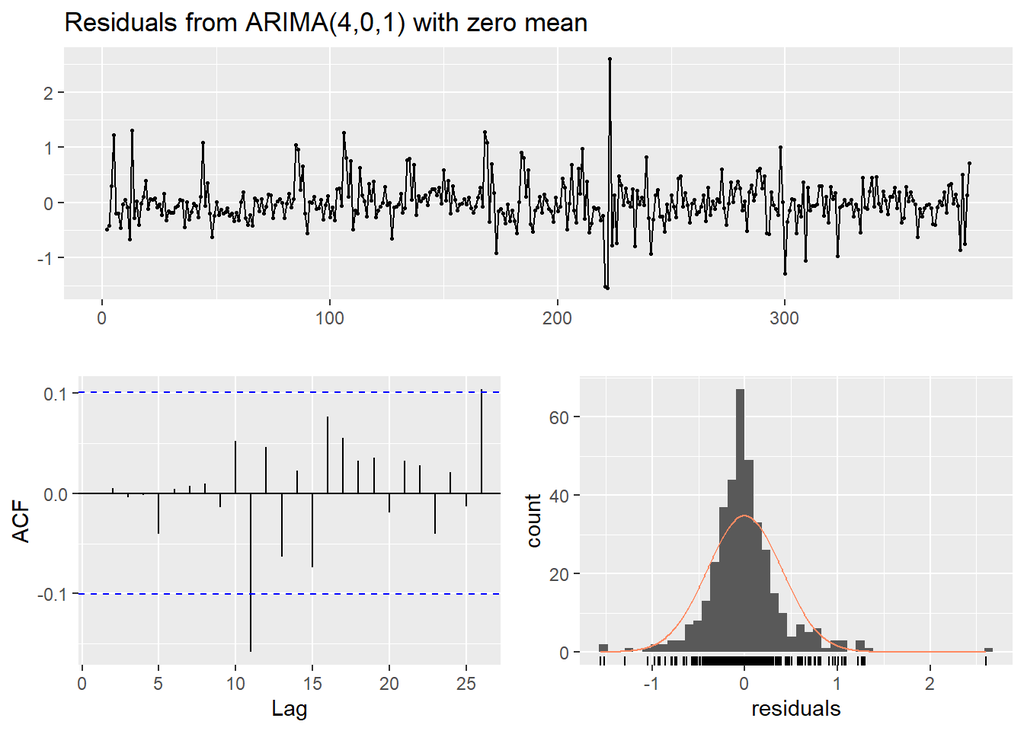

```
##
##  Ljung-Box test
##
## data:  Residuals from ARIMA(4,0,1) with zero mean
## Q* = 1.886, df = 5, p-value = 0.8647
##
## Model df: 5.   Total lags used: 10
```

```r
checkresiduals(model_4$model)
```

```r
reg1 = data.frame(wday=data_4[.N,ifelse(wday<7,wday+1,1)])
reg2 = data.frame(wday=data_4[.N,ifelse(wday<6,wday+2,ifelse(wday==6,1,2))])
fcst[1,4] = round(exp(model_4$forecast[2]+
                      model_4$forecast[1]+
                      predict(lm_4_1,reg1)+
                      predict(lm_4_1,reg2)+
                      data_4[.N,c(log_sold_count)]),
                  0)
```

Regarding the available information, the model seems to be adequate in terms of its residuals.

### Product 5

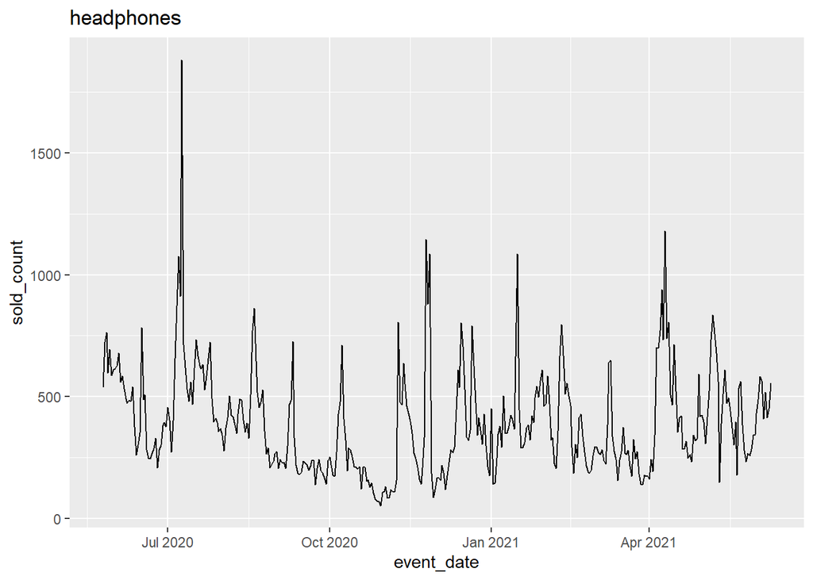

```r
ggplot(data_5, aes(x=event_date, y=sold_count)) + geom_line() + labs(title = "headphones")
```

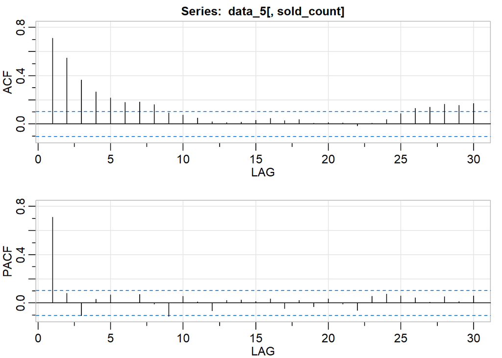

```
##      [,1] [,2]  [,3] [,4] [,5] [,6] [,7]  [,8]  [,9] [,10] [,11] [,12] [,13]
## ACF  0.71 0.55  0.37 0.27 0.22 0.18 0.18  0.16  0.09  0.08  0.05  0.02  0.01
## PACF 0.71 0.08 -0.10 0.03 0.07 0.00 0.07 -0.01 -0.11  0.06  0.01 -0.06  0.02
##      [,14] [,15] [,16] [,17] [,18] [,19] [,20] [,21] [,22] [,23] [,24] [,25]
## ACF   0.02  0.03  0.05  0.03  0.04  0.01  0.02  0.01 -0.01  0.01  0.04  0.09
## PACF  0.03  0.01  0.03 -0.05  0.02 -0.03  0.04 -0.01 -0.06  0.06  0.08  0.06
##      [,26] [,27] [,28] [,29] [,30]
## ACF   0.13  0.14  0.16  0.16  0.17
## PACF  0.04  0.01  0.05  0.01  0.06
```

```r
acf2(data_5[,sold_count])
```

There is not seasonality effect either. It may be transformed using Box-Cox transformation.

```r
BoxCox.lambda(data_5[,sold_count], lower=0)
```

```
## [1] 4.102259e-05
```

It is very close to zero, so a log transformation is appropriate.

```r
data_5[,log_sold_count:=log(sold_count)]
summary(ur.kpss(data_5[,log_sold_count]))
```

```
##
## #######################
## # KPSS Unit Root Test #
## #######################
##
## Test is of type: mu with 5 lags.
##
## Value of test-statistic is: 0.4429
##
## Critical value for a significance level of:
##                 10pct  5pct 2.5pct  1pct
## critical values 0.347 0.463  0.574 0.739
```

The data does not seem to be stationary as the unit root test suggests.

```r
data_5[,lag_log_sold_count:=shift(log_sold_count,1)]
data_5[,dl_sold_count:=log_sold_count-lag_log_sold_count]
summary(ur.kpss(data_5[,dl_sold_count]))
```

```
##
## #######################
## # KPSS Unit Root Test #
## #######################
##
## Test is of type: mu with 5 lags.
##
## Value of test-statistic is: 0.021
##
## Critical value for a significance level of:
##                 10pct  5pct 2.5pct  1pct
## critical values 0.347 0.463  0.574 0.739
```

Now, stationarity can be assumed. At this point, a linear model can be fitted to the series. In order to use `basket_count`, it should be differenced as well. Also note the use of lagged differenced `basket_count`, since forecast for 2 periods ahead is needed.

```r
data_5[,lag_basket_count:=shift(basket_count,1)]
data_5[,diff_basket_count:=basket_count-lag_basket_count]
data_5[,lag2_basket_count:=shift(basket_count,2)]
data_5[,lag2_diff_basket_count:=shift(diff_basket_count,2)]
lm_5_1 = lm(dl_sold_count~lag2_diff_basket_count+special+as.factor(wday), data_5)
anova(lm_5_1)
```

```
## Analysis of Variance Table
##
## Response: dl_sold_count
##                         Df Sum Sq  Mean Sq F value  Pr(>F)
## lag2_diff_basket_count   1  0.003 0.003051  0.0272 0.86913
## special                  1  0.013 0.012625  0.1125 0.73752
## as.factor(wday)          6  1.775 0.295832  2.6359 0.01626 *
## Residuals              369 41.414 0.112232
## ---
## Signif. codes:  0 '***' 0.001 '**' 0.01 '*' 0.05 '.' 0.1 ' ' 1
```

Those variables does not seem to be related with sales. Now, the original series is tried to be modeled linearly.

```r
lm_5_2 = lm(sold_count~as.factor(special)+as.factor(wday)+lag2_basket_count, data_5)
anova(lm_5_2)
```

```
## Analysis of Variance Table
##
## Response: sold_count
##                     Df   Sum Sq Mean Sq  F value    Pr(>F)
## as.factor(special)   1   508639  508639  15.3104 0.0001085 ***
## as.factor(wday)      6   278154   46359   1.3954 0.2153205
## lag2_basket_count    1  4562395 4562395 137.3313 < 2.2e-16 ***
## Residuals          370 12292071   33222
## ---
## Signif. codes:  0 '***' 0.001 '**' 0.01 '*' 0.05 '.' 0.1 ' ' 1
```

If only the important variables to be used,

```r
lm_5_2 = lm(sold_count~as.factor(special)+lag2_basket_count, data_5)
summary(lm_5_2)
```

```
##
## Call:
## lm(formula = sold_count ~ as.factor(special) + lag2_basket_count,
##     data = data_5)
##
## Residuals:
##     Min      1Q  Median      3Q     Max
## -686.81 -113.30  -32.16   90.32 1144.56
##
## Coefficients:
##                      Estimate Std. Error t value Pr(>|t|)
## (Intercept)         166.31751   21.40930   7.768 7.64e-14 ***
## as.factor(special)1  73.05860   44.06424   1.658   0.0982 .
## lag2_basket_count     0.14440    0.01262  11.439  < 2e-16 ***
## ---
## Signif. codes:  0 '***' 0.001 '**' 0.01 '*' 0.05 '.' 0.1 ' ' 1
##
## Residual standard error: 183.9 on 376 degrees of freedom
##   (2 observations deleted due to missingness)
## Multiple R-squared:  0.2796, Adjusted R-squared:  0.2757
## F-statistic: 72.95 on 2 and 376 DF,  p-value: < 2.2e-16
```

`special` variable does not seem to be effective.

```r
lm_5_2 = lm(sold_count~lag2_basket_count, data_5)
summary(lm_5_2)
```

```
##
## Call:
## lm(formula = sold_count ~ lag2_basket_count, data = data_5)
##
## Residuals:
##     Min      1Q  Median      3Q     Max
## -625.90 -114.89  -32.73   87.64 1131.38
##
## Coefficients:
##                    Estimate Std. Error t value Pr(>|t|)
## (Intercept)       163.89609   21.40892   7.656 1.63e-13 ***
## lag2_basket_count   0.14834    0.01243  11.937  < 2e-16 ***
## ---
## Signif. codes:  0 '***' 0.001 '**' 0.01 '*' 0.05 '.' 0.1 ' ' 1
##
## Residual standard error: 184.3 on 377 degrees of freedom
##   (2 observations deleted due to missingness)
## Multiple R-squared:  0.2743, Adjusted R-squared:  0.2724
## F-statistic: 142.5 on 1 and 377 DF,  p-value: < 2.2e-16
```

```r
data_5[,res:=c(rep(NA,2),residuals(lm_5_2))]
summary(ur.kpss(data_5[,res]))
```

```
##
## #######################
## # KPSS Unit Root Test #
## #######################
##
## Test is of type: mu with 5 lags.
##
## Value of test-statistic is: 0.4803
##
## Critical value for a significance level of:
##                 10pct  5pct 2.5pct  1pct
## critical values 0.347 0.463  0.574 0.739
```

Differencing can be performed since the value of test-statistic is somehow large.

```r
data_5[,lag_res:=shift(res,1)]
data_5[,d_res:=res-lag_res]
summary(ur.kpss(data_5[,d_res]))
```

```
##
## #######################
## # KPSS Unit Root Test #
## #######################
##
## Test is of type: mu with 5 lags.
##
## Value of test-statistic is: 0.0248
##
## Critical value for a significance level of:
##                 10pct  5pct 2.5pct  1pct
## critical values 0.347 0.463  0.574 0.739
```

Test statistic is small now, suggesting stationarity.

In order to compare the models,

```r
results=vector('list',length(test_dates))
for(i in 1:length(test_dates)){
  current_date=test_dates[i]-forecast_ahead

  past_data=data_5[event_date<=current_date]
  forecast_data=data_5[event_date==test_dates[i]]

  # arima model
  frcst=forecast_with_arima(past_data, forecast_ahead, target_name = "dl_sold_count", is_trace = F)
  forecast_data[,arima_prediction:=round(exp(frcst$forecast[2]+
                                             frcst$forecast[1]+
                                             past_data[.N,c(log_sold_count)]),
                                         0)]

  # arimax model (not exactly arimax)
  frcst=forecast_with_arima(past_data, forecast_ahead, target_name = "d_res", is_trace = F)
  reg = data.frame(lag2_basket_count=past_data[.N,basket_count])
  forecast_data[,arimax_prediction:=round(frcst$forecast[2]+
                                          frcst$forecast[1]+
                                          predict(lm_5_2,reg)+
                                          past_data[.N,res],
                                          0)]

  results[[i]]=forecast_data
}
overall_results=rbindlist(results)
melted_result_5=melt(overall_results,c('event_date','sold_count'),
                     c('arima_prediction','arimax_prediction'))
performance_5= melted_result_5[,accu(sold_count,value),by=list(variable)]
performance_5
```

```
##             variable  n     mean       sd       CV      FBias      MAPE
## 1:  arima_prediction 21 404.0476 123.3452 0.305274 0.05598114 0.2639002
## 2: arimax_prediction 21 404.0476 123.3452 0.305274 0.03028874 0.2501435
##        RMSE      MAD      MADP     WMAPE
## 1: 126.9404 98.71429 0.2443135 0.2443135
## 2: 109.0384 90.52381 0.2240424 0.2240424
```

The second model is better, it will be used to make forecasts.

```r
model_5=forecast_with_arima(data_5,forecast_ahead = 2, target_name = "d_res")
```

```
##
##  ARIMA(0,0,0) with zero mean     : 5000.214
##  ARIMA(0,0,0) with non-zero mean : 5002.233
##  ARIMA(0,0,1) with zero mean     : 4985.824
##  ARIMA(0,0,1) with non-zero mean : 4987.85
##  ARIMA(0,0,2) with zero mean     : 4892.257
##  ARIMA(0,0,2) with non-zero mean : 4894.081
##  ARIMA(0,0,3) with zero mean     : 4892.062
##  ARIMA(0,0,3) with non-zero mean : 4893.884
##  ARIMA(0,0,4) with zero mean     : 4892.878
##  ARIMA(0,0,4) with non-zero mean : 4894.701
##  ARIMA(0,0,5) with zero mean     : 4892.505
##  ARIMA(0,0,5) with non-zero mean : 4894.358
##  ARIMA(1,0,0) with zero mean     : 4996.552
##  ARIMA(1,0,0) with non-zero mean : 4998.582
##  ARIMA(1,0,1) with zero mean     : 4903.347
##  ARIMA(1,0,1) with non-zero mean : 4905.138
##  ARIMA(1,0,2) with zero mean     : 4891.691
##  ARIMA(1,0,2) with non-zero mean : 4893.509
##  ARIMA(1,0,3) with zero mean     : 4893.737
##  ARIMA(1,0,3) with non-zero mean : 4895.566
##  ARIMA(1,0,4) with zero mean     : 4893.518
##  ARIMA(1,0,4) with non-zero mean : 4895.354
##  ARIMA(2,0,0) with zero mean     : 4966.53
##  ARIMA(2,0,0) with non-zero mean : 4968.568
##  ARIMA(2,0,1) with zero mean     : 4891.997
##  ARIMA(2,0,1) with non-zero mean : 4893.827
##  ARIMA(2,0,2) with zero mean     : 4893.521
##  ARIMA(2,0,2) with non-zero mean : 4895.344
##  ARIMA(2,0,3) with zero mean     : 4894.711
##  ARIMA(2,0,3) with non-zero mean : 4896.547
##  ARIMA(3,0,0) with zero mean     : 4958.945
##  ARIMA(3,0,0) with non-zero mean : 4960.993
##  ARIMA(3,0,1) with zero mean     : 4894.024
##  ARIMA(3,0,1) with non-zero mean : 4895.864
##  ARIMA(3,0,2) with zero mean     : 4893.654
##  ARIMA(3,0,2) with non-zero mean : 4895.499
##  ARIMA(4,0,0) with zero mean     : 4941.313
##  ARIMA(4,0,0) with non-zero mean : 4943.368
##  ARIMA(4,0,1) with zero mean     : 4894.049
##  ARIMA(4,0,1) with non-zero mean : 4895.915
##  ARIMA(5,0,0) with zero mean     : 4938.245
##  ARIMA(5,0,0) with non-zero mean : 4940.31
##
##
##
##  Best model: ARIMA(1,0,2) with zero mean
```

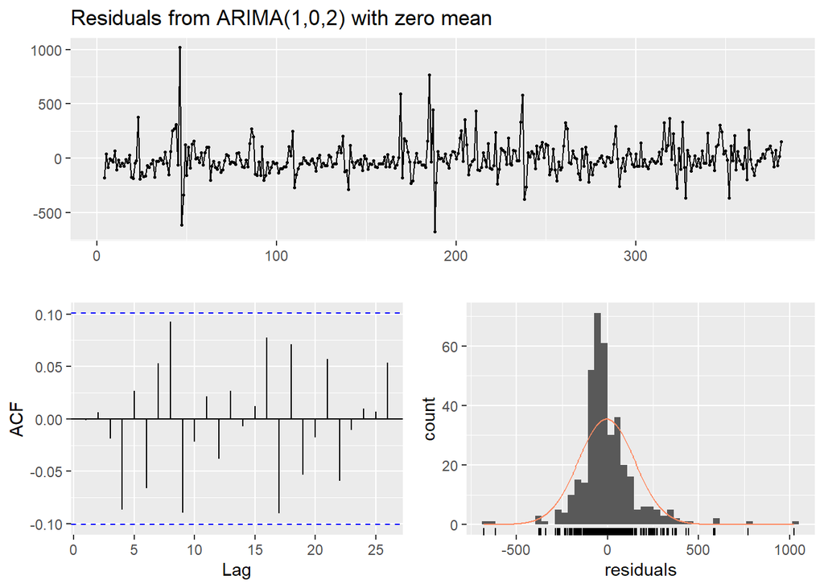

```
##
##  Ljung-Box test
##
## data:  Residuals from ARIMA(1,0,2) with zero mean
## Q* = 12.769, df = 7, p-value = 0.07793
##
## Model df: 3.   Total lags used: 10
```

```r
checkresiduals(model_5$model)
```

```r
reg = data.frame(lag2_basket_count=data_5[.N,basket_count])
fcst[1,5] = round(model_5$forecast[2]+
                model_5$forecast[1]+
                predict(lm_5_2,reg)+
                data_5[.N,c(res)],
                0)
```

Regarding the available information, the model seems to be adequate in terms of its residuals.

### Product 6

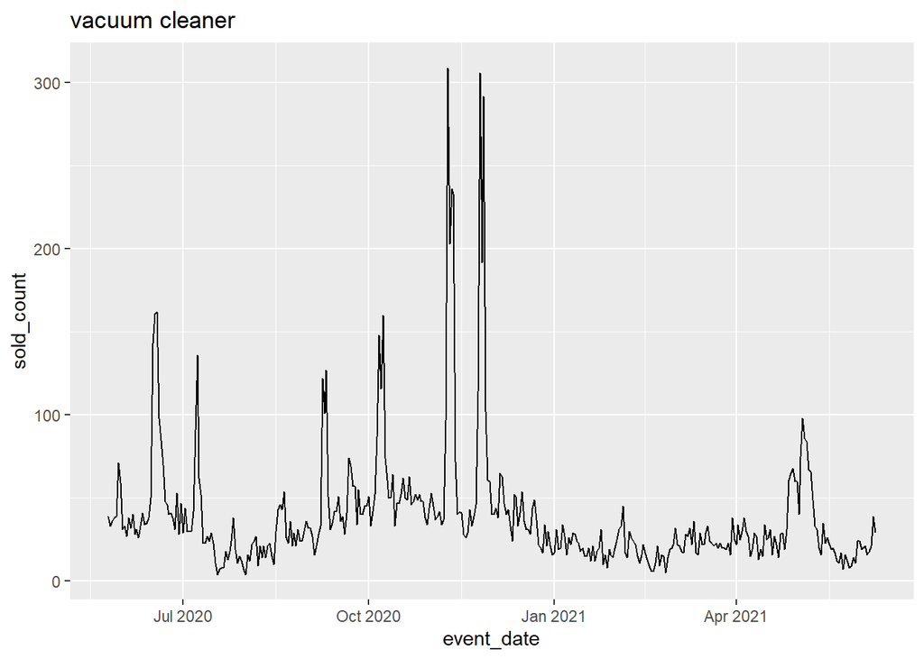

```r
ggplot(data_6, aes(x=event_date, y=sold_count)) + geom_line() + labs(title = "vacuum cleaner")
```

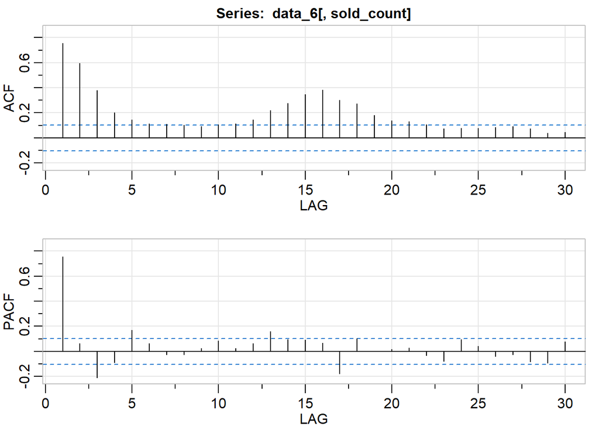

```
##      [,1] [,2]  [,3]  [,4] [,5] [,6]  [,7]  [,8] [,9] [,10] [,11] [,12] [,13]
## ACF  0.75 0.60  0.38  0.20 0.14 0.11  0.11  0.10 0.09  0.11  0.11  0.15  0.22
## PACF 0.75 0.06 -0.21 -0.09 0.17 0.06 -0.03 -0.03 0.02  0.09  0.02  0.06  0.16
##      [,14] [,15] [,16] [,17] [,18] [,19] [,20] [,21] [,22] [,23] [,24] [,25]
## ACF   0.28  0.35  0.38  0.30  0.27  0.18  0.14  0.13  0.10  0.07  0.08  0.08
## PACF  0.09  0.09  0.06 -0.18  0.10  0.00  0.02  0.03 -0.03 -0.08  0.10  0.04
##      [,26] [,27] [,28] [,29] [,30]
## ACF   0.08  0.09  0.07  0.04  0.04
## PACF -0.04 -0.03 -0.08 -0.09  0.08
```

```r
acf2(data_6[,sold_count])
```

Same situation arises here. Lag 16 does not correspond to any seasonality. It may be transformed using Box-Cox transformation.

```r
BoxCox.lambda(data_6[,sold_count], lower=0)
```

```
## [1] 4.102259e-05
```

It is very close to zero, so a log transformation can be appropriate.

```r
data_6[,log_sold_count:=log(sold_count)]
summary(ur.kpss(data_6[,log_sold_count]))
```

```
##
## #######################
## # KPSS Unit Root Test #
## #######################
##
## Test is of type: mu with 5 lags.
##
## Value of test-statistic is: 0.8704
##
## Critical value for a significance level of:
##                 10pct  5pct 2.5pct  1pct
## critical values 0.347 0.463  0.574 0.739
```

The data does not seem to be stationary as the unit root test suggests.

```r
data_6[,lag_log_sold_count:=shift(log_sold_count,1)]
data_6[,dl_sold_count:=log_sold_count-lag_log_sold_count]
summary(ur.kpss(data_6[,dl_sold_count]))
```

```
##
## #######################
## # KPSS Unit Root Test #
## #######################
##
## Test is of type: mu with 5 lags.
##
## Value of test-statistic is: 0.0138
##
## Critical value for a significance level of:
##                 10pct  5pct 2.5pct  1pct
## critical values 0.347 0.463  0.574 0.739
```

Now, stationarity can be assumed. At this point, a linear model can be fitted to the series. In order to use `basket_count`, it should be differenced as well. Also note the use of lagged differenced `basket_count`, since forecast for 2 periods ahead is needed.

```r
data_6[,lag_basket_count:=shift(basket_count,1)]
data_6[,diff_basket_count:=basket_count-lag_basket_count]
data_6[,lag2_basket_count:=shift(basket_count,2)]
data_6[,lag2_diff_basket_count:=shift(diff_basket_count,2)]
lm_6_1 = lm(dl_sold_count~lag2_diff_basket_count+special+as.factor(wday), data_6)
anova(lm_6_1)
```

```
## Analysis of Variance Table
##
## Response: dl_sold_count
##                         Df Sum Sq Mean Sq F value    Pr(>F)
## lag2_diff_basket_count   1  0.022 0.02176  0.1313    0.7173
## special                  1  0.058 0.05802  0.3502    0.5544
## as.factor(wday)          6  4.800 0.80008  4.8288 9.228e-05 ***
## Residuals              369 61.139 0.16569
## ---
## Signif. codes:  0 '***' 0.001 '**' 0.01 '*' 0.05 '.' 0.1 ' ' 1
```

Only `wday` variable seems to be important.

```r
lm_6_1 = lm(dl_sold_count~as.factor(wday), data_6)
summary(lm_6_1)
```

```
##
## Call:
## lm(formula = dl_sold_count ~ as.factor(wday), data = data_6)
##
## Residuals:
##      Min       1Q   Median       3Q      Max
## -1.08581 -0.25226  0.00508  0.22862  1.22339
##
## Coefficients:
##                   Estimate Std. Error t value Pr(>|t|)
## (Intercept)       0.162905   0.055183   2.952  0.00336 **
## as.factor(wday)2 -0.208497   0.078040  -2.672  0.00788 **
## as.factor(wday)3 -0.003252   0.077685  -0.042  0.96663
## as.factor(wday)4 -0.199493   0.077685  -2.568  0.01062 *
## as.factor(wday)5 -0.237912   0.078040  -3.049  0.00246 **
## as.factor(wday)6 -0.323073   0.078040  -4.140  4.3e-05 ***
## as.factor(wday)7 -0.175874   0.078040  -2.254  0.02480 *
## ---
## Signif. codes:  0 '***' 0.001 '**' 0.01 '*' 0.05 '.' 0.1 ' ' 1
##
## Residual standard error: 0.4055 on 373 degrees of freedom
##   (1 observation deleted due to missingness)
## Multiple R-squared:  0.07144,    Adjusted R-squared:  0.0565
## F-statistic: 4.783 on 6 and 373 DF,  p-value: 0.0001028
```

```r
data_6[,res_1:=c(NA,lm_6_1$residuals)]
```

So far, a linear model is fitted to differenced and transformed series. Now, as another modeling strategy, the original series is tried to be modeled linearly.

```r
lm_6_2 = lm(sold_count~as.factor(special)+as.factor(wday)+lag2_basket_count, data_6)
anova(lm_6_2)
```

```
## Analysis of Variance Table
##
## Response: sold_count
##                     Df Sum Sq Mean Sq  F value  Pr(>F)
## as.factor(special)   1 184625  184625 252.0706 < 2e-16 ***
## as.factor(wday)      6   9120    1520   2.0753 0.05534 .
## lag2_basket_count    1 107572  107572 146.8688 < 2e-16 ***
## Residuals          370 271001     732
## ---
## Signif. codes:  0 '***' 0.001 '**' 0.01 '*' 0.05 '.' 0.1 ' ' 1
```

If only the important variables to be used,

```r
lm_6_2 = lm(sold_count~as.factor(special)+lag2_basket_count, data_6)
summary(lm_6_2)
```

```
##
## Call:
## lm(formula = sold_count ~ as.factor(special) + lag2_basket_count,
##     data = data_6)
##
## Residuals:
##      Min       1Q   Median       3Q      Max
## -111.140   -9.823   -3.361    5.326  194.431
##
## Coefficients:
##                     Estimate Std. Error t value Pr(>|t|)
## (Intercept)         10.61533    2.45692   4.321 1.99e-05 ***
## as.factor(special)1 44.76093    7.99784   5.597 4.22e-08 ***
## lag2_basket_count    0.18244    0.01533  11.897  < 2e-16 ***
## ---
## Signif. codes:  0 '***' 0.001 '**' 0.01 '*' 0.05 '.' 0.1 ' ' 1
##
## Residual standard error: 27.37 on 376 degrees of freedom
##   (2 observations deleted due to missingness)
## Multiple R-squared:  0.5079, Adjusted R-squared:  0.5052
## F-statistic:   194 on 2 and 376 DF,  p-value: < 2.2e-16
```

```r
data_6[,res_2:=c(rep(NA,2),residuals(lm_6_2))]
summary(ur.kpss(data_6[,res_2]))
```

```
##
## #######################
## # KPSS Unit Root Test #
## #######################
##
## Test is of type: mu with 5 lags.
##
## Value of test-statistic is: 0.5673
##
## Critical value for a significance level of:
##                 10pct  5pct 2.5pct  1pct
## critical values 0.347 0.463  0.574 0.739
```

Test statistic is large and differencing is required.

```r
data_6[,lag_res_2:=shift(res_2,1)]
data_6[,d_res_2:=res_2-lag_res_2]
summary(ur.kpss(data_6[,d_res_2]))
```

```
##
## #######################
## # KPSS Unit Root Test #
## #######################
##
## Test is of type: mu with 5 lags.
##
## Value of test-statistic is: 0.0079
##
## Critical value for a significance level of:
##                 10pct  5pct 2.5pct  1pct
## critical values 0.347 0.463  0.574 0.739
```

In order to compare the models,

```r
results=vector('list',length(test_dates))
for(i in 1:length(test_dates)){
  current_date=test_dates[i]-forecast_ahead

  past_data=data_6[event_date<=current_date]
  forecast_data=data_6[event_date==test_dates[i]]

  # arima model
  frcst=forecast_with_arima(past_data, forecast_ahead, target_name = "dl_sold_count", is_trace = F)
  forecast_data[,arima_prediction:=round(exp(frcst$forecast[2]+
                                             frcst$forecast[1]+
                                             past_data[.N,c(log_sold_count)]),
                                         0)]
  # arimax model (wday)(not exactly arimax)
  frcst=forecast_with_arima(past_data, forecast_ahead, target_name = "res_1", is_trace = F)
  reg1 = data.frame(wday=past_data[.N,ifelse(wday<7,wday+1,1)])
  reg2 = data.frame(wday=past_data[.N,ifelse(wday<6,wday+2,ifelse(wday==6,1,2))])
  forecast_data[,arimax_prediction_1:=round(exp(frcst$forecast[2]+
                                                frcst$forecast[1]+
                                                predict(lm_6_1,reg1)+
                                                predict(lm_6_1,reg2)+
                                                past_data[.N,c(log_sold_count)]),
                                            0)]

  # arimax model (special)(not exactly arimax)
  frcst=forecast_with_arima(past_data, forecast_ahead, target_name = "d_res_2", is_trace = F)
  reg = data.frame(special=as.factor(forecast_data[1,special]),
                   lag2_basket_count=past_data[.N,lag2_basket_count])
  forecast_data[,arimax_prediction_2:=round(frcst$forecast[2]+
                                            frcst$forecast[1]+
                                            predict(lm_6_2,reg)+
                                            past_data[.N,res_2],
                                            0)]


  results[[i]]=forecast_data
}
overall_results=rbindlist(results)
melted_result_6=melt(overall_results,c('event_date','sold_count'),
                     c('arima_prediction','arimax_prediction_1','arimax_prediction_2'))
performance_6= melted_result_6[,accu(sold_count,value),by=list(variable)]
performance_6
```

```
##               variable  n     mean       sd        CV       FBias      MAPE
## 1:    arima_prediction 21 17.38095 7.572821 0.4356966 -0.04383562 0.4143522
## 2: arimax_prediction_1 21 17.38095 7.572821 0.4356966 -0.02465753 0.3798978
## 3: arimax_prediction_2 21 17.38095 7.572821 0.4356966 -0.28493151 0.6652809
##         RMSE      MAD      MADP     WMAPE
## 1:  8.000000 6.095238 0.3506849 0.3506849
## 2:  7.148093 5.666667 0.3260274 0.3260274
## 3: 10.300254 8.476190 0.4876712 0.4876712
```

The second model is the best among these three.

```r
model_6=forecast_with_arima(data_6,forecast_ahead = 2, target_name = "res_1")
```

```
##
##  ARIMA(0,0,0) with zero mean     : 387.3544
##  ARIMA(0,0,0) with non-zero mean : 389.3756
##  ARIMA(0,0,1) with zero mean     : 368.8239
##  ARIMA(0,0,1) with non-zero mean : 370.8556
##  ARIMA(0,0,2) with zero mean     : 370.6015
##  ARIMA(0,0,2) with non-zero mean : 372.644
##  ARIMA(0,0,3) with zero mean     : 368.7263
##  ARIMA(0,0,3) with non-zero mean : 370.7801
##  ARIMA(0,0,4) with zero mean     : 355.0556
##  ARIMA(0,0,4) with non-zero mean : 357.115
##  ARIMA(0,0,5) with zero mean     : 344.7429
##  ARIMA(0,0,5) with non-zero mean : 346.798
##  ARIMA(1,0,0) with zero mean     : 369.9652
##  ARIMA(1,0,0) with non-zero mean : 371.9969
##  ARIMA(1,0,1) with zero mean     : 353.1477
##  ARIMA(1,0,1) with non-zero mean : 355.1703
##  ARIMA(1,0,2) with zero mean     : 352.0348
##  ARIMA(1,0,2) with non-zero mean : 354.0739
##  ARIMA(1,0,3) with zero mean     : 351.0198
##  ARIMA(1,0,3) with non-zero mean : 353.0663
##  ARIMA(1,0,4) with zero mean     : 348.6851
##  ARIMA(1,0,4) with non-zero mean : 350.7404
##  ARIMA(2,0,0) with zero mean     : 371.311
##  ARIMA(2,0,0) with non-zero mean : 373.3535
##  ARIMA(2,0,1) with zero mean     : 351.3135
##  ARIMA(2,0,1) with non-zero mean : 353.3533
##  ARIMA(2,0,2) with zero mean     : 352.8432
##  ARIMA(2,0,2) with non-zero mean : 354.8927
##  ARIMA(2,0,3) with zero mean     : 350.6601
##  ARIMA(2,0,3) with non-zero mean : 352.7163
##  ARIMA(3,0,0) with zero mean     : 373.0878
##  ARIMA(3,0,0) with non-zero mean : 375.1413
##  ARIMA(3,0,1) with zero mean     : 352.0889
##  ARIMA(3,0,1) with non-zero mean : 354.1352
##  ARIMA(3,0,2) with zero mean     : 353.3779
##  ARIMA(3,0,2) with non-zero mean : 355.4388
##  ARIMA(4,0,0) with zero mean     : 372.6419
##  ARIMA(4,0,0) with non-zero mean : 374.7065
##  ARIMA(4,0,1) with zero mean     : 350.9466
##  ARIMA(4,0,1) with non-zero mean : 353.003
##  ARIMA(5,0,0) with zero mean     : 355.8754
##  ARIMA(5,0,0) with non-zero mean : 357.9511
##
##
##
##  Best model: ARIMA(0,0,5) with zero mean
```

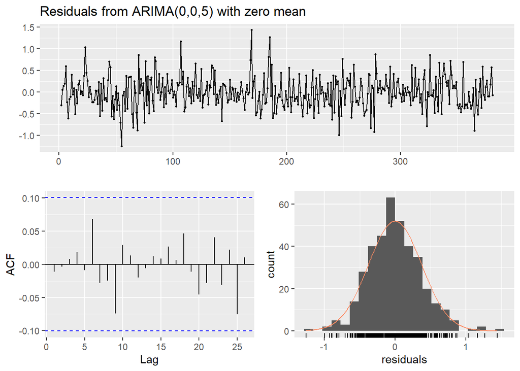

```
##
##  Ljung-Box test
##
## data:  Residuals from ARIMA(0,0,5) with zero mean
## Q* = 5.0719, df = 5, p-value = 0.4072
##
## Model df: 5.   Total lags used: 10
```

```r
checkresiduals(model_6$model)
```

```r
reg1 = data.frame(wday=data_6[.N,ifelse(wday<7,wday+1,1)])
reg2 = data.frame(wday=data_6[.N,ifelse(wday<6,wday+2,ifelse(wday==6,1,2))])
fcst[1,6] = round(exp(model_6$forecast[2]+
                    model_6$forecast[1]+
                    predict(lm_6_1,reg1)+
                    predict(lm_6_1,reg2)+
                    data_6[.N,c(log_sold_count)]),
                0)
```

Regarding the available information, the model seems to be adequate in terms of its residuals.

### Product 7

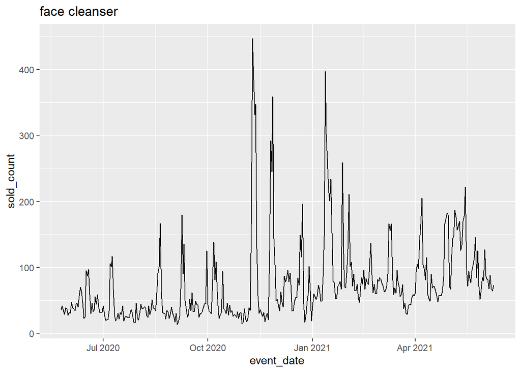

```r
ggplot(data_7, aes(x=event_date, y=sold_count)) + geom_line() + labs(title = "face cleanser")
```

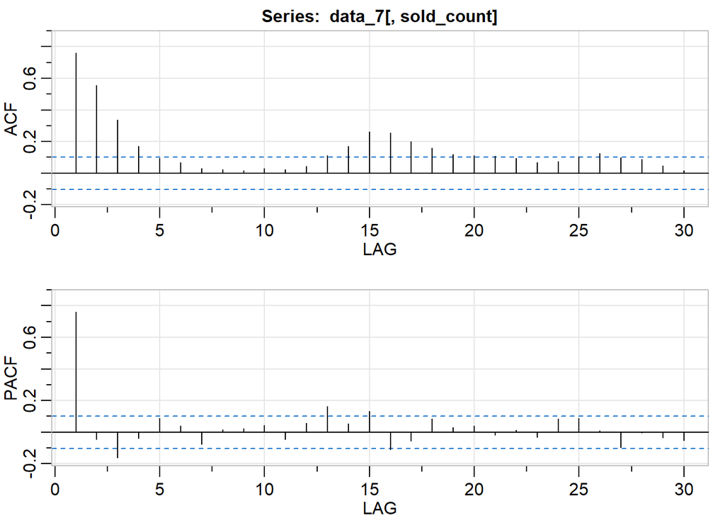

```
##      [,1]  [,2]  [,3]  [,4] [,5] [,6]  [,7] [,8] [,9] [,10] [,11] [,12] [,13]
## ACF  0.76  0.56  0.34  0.17 0.09 0.07  0.03 0.02 0.02  0.03  0.02  0.04  0.11
## PACF 0.76 -0.05 -0.16 -0.04 0.09 0.04 -0.08 0.02 0.02  0.04 -0.05  0.06  0.16
##      [,14] [,15] [,16] [,17] [,18] [,19] [,20] [,21] [,22] [,23] [,24] [,25]
## ACF   0.17  0.26  0.26  0.20  0.16  0.12  0.11  0.11  0.10  0.07  0.07  0.10
## PACF  0.05  0.13 -0.11 -0.05  0.08  0.03  0.04 -0.02  0.01 -0.03  0.09  0.09
##      [,26] [,27] [,28] [,29] [,30]
## ACF   0.13   0.1  0.09  0.05  0.02
## PACF  0.01  -0.1 -0.01 -0.03 -0.05
```

```r
acf2(data_7[,sold_count])
```

There is not seasonality effect. It may be transformed using Box-Cox transformation.

```r
BoxCox.lambda(data_7[,sold_count], lower=0)
```

```
## [1] 4.102259e-05
```

It is very close to zero, so a log transformation is appropriate.

```r
data_7[,log_sold_count:=log(sold_count)]
summary(ur.kpss(data_7[,log_sold_count]))
```

```
##
## #######################
## # KPSS Unit Root Test #
## #######################
##
## Test is of type: mu with 5 lags.
##
## Value of test-statistic is: 2.9009
##
## Critical value for a significance level of:
##                 10pct  5pct 2.5pct  1pct
## critical values 0.347 0.463  0.574 0.739
```

The data does not seem to be stationary as the unit root test suggests.

```r
data_7[,lag_log_sold_count:=shift(log_sold_count,1)]
data_7[,dl_sold_count:=log_sold_count-lag_log_sold_count]
summary(ur.kpss(data_7[,dl_sold_count]))
```

```
##
## #######################
## # KPSS Unit Root Test #
## #######################
##
## Test is of type: mu with 5 lags.
##
## Value of test-statistic is: 0.0084
##
## Critical value for a significance level of:
##                 10pct  5pct 2.5pct  1pct
## critical values 0.347 0.463  0.574 0.739
```

Now, stationarity can be assumed. At this point, a linear model can be fitted to the series. In order to use `basket_count`, it should be differenced as well. Also note the use of lagged differenced `basket_count`, since forecast for 2 periods ahead is needed.

```r
data_7[,lag_basket_count:=shift(basket_count,1)]
data_7[,diff_basket_count:=basket_count-lag_basket_count]
data_7[,lag2_basket_count:=shift(basket_count,2)]
data_7[,lag2_diff_basket_count:=shift(diff_basket_count,2)]
lm_7_1 = lm(dl_sold_count~lag2_diff_basket_count+special+as.factor(wday), data_7)
anova(lm_7_1)
```

```
## Analysis of Variance Table
##
## Response: dl_sold_count
##                         Df Sum Sq Mean Sq F value   Pr(>F)
## lag2_diff_basket_count   1  0.155 0.15477  0.8602 0.354278
## special                  1  0.005 0.00460  0.0256 0.873048
## as.factor(wday)          6  3.702 0.61692  3.4289 0.002627 **
## Residuals              369 66.389 0.17992
## ---
## Signif. codes:  0 '***' 0.001 '**' 0.01 '*' 0.05 '.' 0.1 ' ' 1
```

Only `wday` variable seems to be important but since it could not be explained intuitively, it is not used unless it is highly significant.

Now, as another modeling strategy, the original series is tried to be modeled linearly.

```r
lm_7_2 = lm(sold_count~as.factor(special)+as.factor(wday)+lag2_basket_count, data_7)
anova(lm_7_2)
```

```
## Analysis of Variance Table
##
## Response: sold_count
##                     Df Sum Sq Mean Sq F value    Pr(>F)
## as.factor(special)   1 171075  171075  71.729 5.888e-16 ***
## as.factor(wday)      6  36491    6082   2.550    0.0197 *
## lag2_basket_count    1 392829  392829 164.706 < 2.2e-16 ***
## Residuals          370 882460    2385
## ---
## Signif. codes:  0 '***' 0.001 '**' 0.01 '*' 0.05 '.' 0.1 ' ' 1
```

If only the important variables are used,

```r
lm_7_2 = lm(sold_count~as.factor(special)+lag2_basket_count, data_7)
summary(lm_7_2)
```

```
##
## Call:
## lm(formula = sold_count ~ as.factor(special) + lag2_basket_count,
##     data = data_7)
##
## Residuals:
##     Min      1Q  Median      3Q     Max
## -122.31  -20.83   -9.08   11.60  327.32
##
## Coefficients:
##                     Estimate Std. Error t value Pr(>|t|)
## (Intercept)         24.11135    4.49545   5.363 1.43e-07 ***
## as.factor(special)1 80.11254   11.77488   6.804 4.03e-11 ***
## lag2_basket_count    0.12983    0.01041  12.473  < 2e-16 ***
## ---
## Signif. codes:  0 '***' 0.001 '**' 0.01 '*' 0.05 '.' 0.1 ' ' 1
##
## Residual standard error: 49.68 on 376 degrees of freedom
##   (2 observations deleted due to missingness)
## Multiple R-squared:  0.3743, Adjusted R-squared:  0.3709
## F-statistic: 112.4 on 2 and 376 DF,  p-value: < 2.2e-16
```

```r
data_7[,res:=c(rep(NA,2),residuals(lm_7_2))]
summary(ur.kpss(data_7[,res]))
```

```
##
## #######################
## # KPSS Unit Root Test #
## #######################
##
## Test is of type: mu with 5 lags.
##
## Value of test-statistic is: 0.1908
##
## Critical value for a significance level of:
##                 10pct  5pct 2.5pct  1pct
## critical values 0.347 0.463  0.574 0.739
```

Small test statistic suggests stationarity.

In order to compare the models,

```r
results=vector('list',length(test_dates))
for(i in 1:length(test_dates)){
  current_date=test_dates[i]-forecast_ahead

  past_data=data_7[event_date<=current_date]
  forecast_data=data_7[event_date==test_dates[i]]

  # arima model
  frcst=forecast_with_arima(past_data, forecast_ahead, target_name = "dl_sold_count", is_trace = F)
  forecast_data[,arima_prediction:=round(exp(frcst$forecast[2]+
                                             frcst$forecast[1]+
                                             past_data[.N,c(log_sold_count)]),
                                         0)]

  # arimax model (special+lag2_basket_count)(not exactly arimax)
  frcst=forecast_with_arima(past_data, forecast_ahead, target_name = "res", is_trace = F)
  reg = data.frame(special=as.factor(forecast_data[1,special]),lag2_basket_count=past_data[.N,lag2_basket_count])
  forecast_data[,arimax_prediction:=round(frcst$forecast[2]+
                                            predict(lm_7_2,reg),
                                            0)]

  results[[i]]=forecast_data
}
overall_results=rbindlist(results)
melted_result_7=melt(overall_results,c('event_date','sold_count'),
                     c('arima_prediction','arimax_prediction'))
performance_7= melted_result_7[,accu(sold_count,value),by=list(variable)]
performance_7
```

```
##             variable  n     mean      sd        CV       FBias      MAPE
## 1:  arima_prediction 21 87.66667 23.5846 0.2690258 -0.06844106 0.2255422
## 2: arimax_prediction 21 87.66667 23.5846 0.2690258 -0.17273221 0.3508791
##        RMSE      MAD      MADP     WMAPE
## 1: 22.28602 17.80952 0.2031505 0.2031505
## 2: 32.90824 28.00000 0.3193916 0.3193916
```

```r
model_7=forecast_with_arima(data_7, forecast_ahead = 2, target_name = "dl_sold_count")
```

```
##
##  ARIMA(0,0,0) with zero mean     : 439.2375
##  ARIMA(0,0,0) with non-zero mean : 441.2516
##  ARIMA(0,0,1) with zero mean     : 440.3517
##  ARIMA(0,0,1) with non-zero mean : 442.3761
##  ARIMA(0,0,2) with zero mean     : 439.5979
##  ARIMA(0,0,2) with non-zero mean : 441.63
##  ARIMA(0,0,3) with zero mean     : 422.866
##  ARIMA(0,0,3) with non-zero mean : 423.2583
##  ARIMA(0,0,4) with zero mean     : 392.6451
##  ARIMA(0,0,4) with non-zero mean : Inf
##  ARIMA(0,0,5) with zero mean     : 388.7323
##  ARIMA(0,0,5) with non-zero mean : Inf
##  ARIMA(1,0,0) with zero mean     : 440.4568
##  ARIMA(1,0,0) with non-zero mean : 442.4813
##  ARIMA(1,0,1) with zero mean     : 396.0382
##  ARIMA(1,0,1) with non-zero mean : Inf
##  ARIMA(1,0,2) with zero mean     : 394.739
##  ARIMA(1,0,2) with non-zero mean : Inf
##  ARIMA(1,0,3) with zero mean     : 393.8057
##  ARIMA(1,0,3) with non-zero mean : Inf
##  ARIMA(1,0,4) with zero mean     : 389.0667
##  ARIMA(1,0,4) with non-zero mean : Inf
##  ARIMA(2,0,0) with zero mean     : 441.3525
##  ARIMA(2,0,0) with non-zero mean : 443.387
##  ARIMA(2,0,1) with zero mean     : 393.7775
##  ARIMA(2,0,1) with non-zero mean : Inf
##  ARIMA(2,0,2) with zero mean     : 389.9762
##  ARIMA(2,0,2) with non-zero mean : Inf
##  ARIMA(2,0,3) with zero mean     : 391.0779
##  ARIMA(2,0,3) with non-zero mean : Inf
##  ARIMA(3,0,0) with zero mean     : 441.1186
##  ARIMA(3,0,0) with non-zero mean : 443.1619
##  ARIMA(3,0,1) with zero mean     : 391.2228
##  ARIMA(3,0,1) with non-zero mean : Inf
##  ARIMA(3,0,2) with zero mean     : 391.3975
##  ARIMA(3,0,2) with non-zero mean : Inf
##  ARIMA(4,0,0) with zero mean     : 427.3328
##  ARIMA(4,0,0) with non-zero mean : 429.3828
##  ARIMA(4,0,1) with zero mean     : 389.6668
##  ARIMA(4,0,1) with non-zero mean : Inf
##  ARIMA(5,0,0) with zero mean     : 422.3087
##  ARIMA(5,0,0) with non-zero mean : 424.3649
##
##
##
##  Best model: ARIMA(0,0,5) with zero mean
```

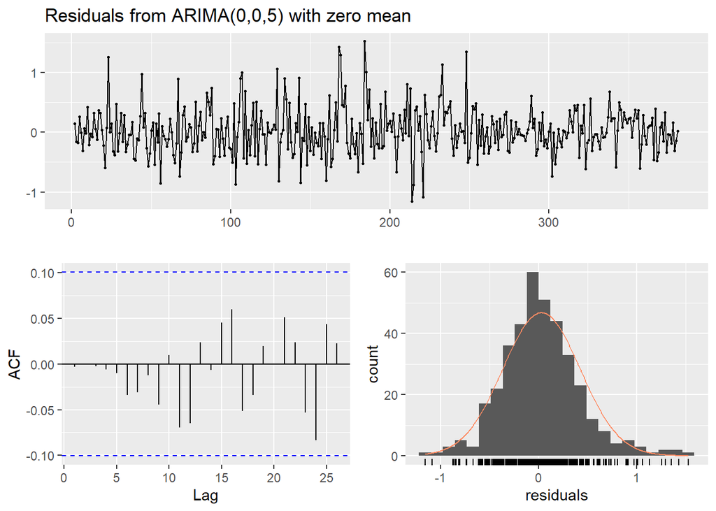

```
##
##  Ljung-Box test
##
## data:  Residuals from ARIMA(0,0,5) with zero mean
## Q* = 1.7658, df = 5, p-value = 0.8805
##
## Model df: 5.   Total lags used: 10
```

```r
checkresiduals(model_7$model)
```

```r
fcst[1,7] = round(exp(model_7$forecast[2]+
                    model_7$forecast[1]+
                    data_7[.N,c(log_sold_count)]),
                0)
```

Regarding the available information, the model seems to be adequate in terms of its residuals.

### Product 8

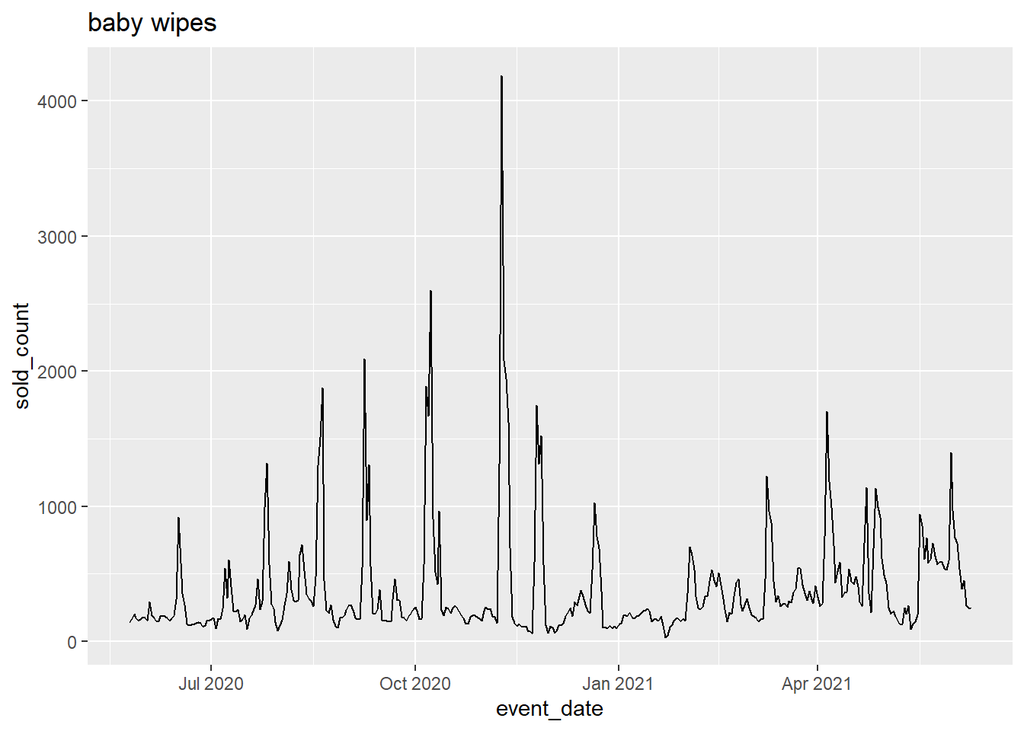

```r
ggplot(data_8, aes(x=event_date, y=sold_count)) + geom_line() + labs(title = "baby wipes")
```

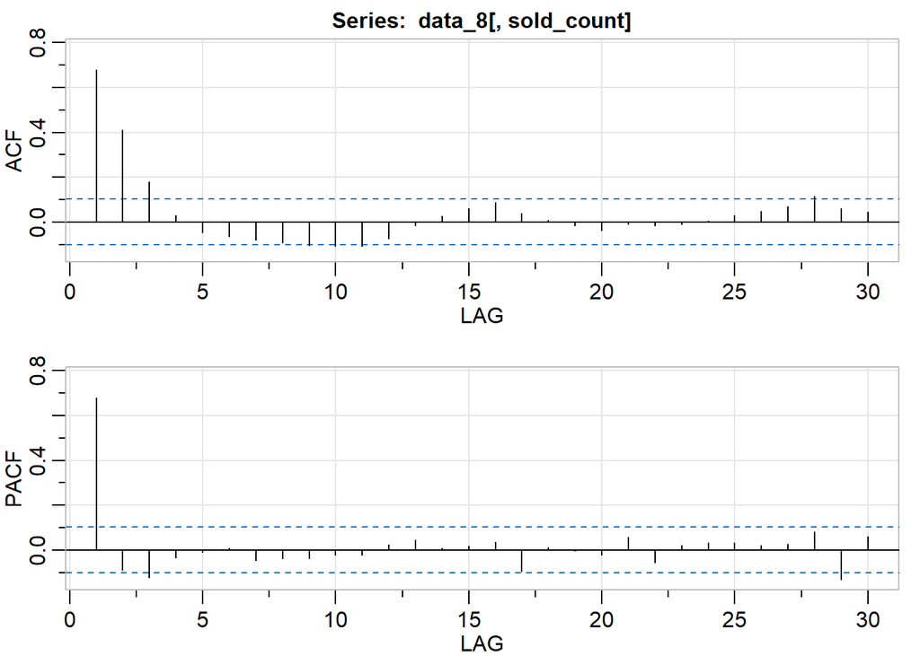

```
##      [,1]  [,2]  [,3]  [,4]  [,5]  [,6]  [,7]  [,8]  [,9] [,10] [,11] [,12]
## ACF  0.68  0.41  0.18  0.03 -0.05 -0.07 -0.08 -0.09 -0.10 -0.11 -0.11 -0.07
## PACF 0.68 -0.09 -0.12 -0.03 -0.01  0.01 -0.05 -0.04 -0.04 -0.02 -0.02  0.02
##      [,13] [,14] [,15] [,16] [,17] [,18] [,19] [,20] [,21] [,22] [,23] [,24]
## ACF  -0.02  0.03  0.06  0.09  0.04  0.01 -0.02 -0.04 -0.01 -0.02 -0.01  0.01
## PACF  0.05  0.01  0.02  0.04 -0.10  0.01  0.00 -0.02  0.06 -0.06  0.02  0.03
##      [,25] [,26] [,27] [,28] [,29] [,30]
## ACF   0.03  0.05  0.07  0.11  0.06  0.05
## PACF  0.03  0.02  0.03  0.08 -0.13  0.06
```

```r
acf2(data_8[,sold_count])
```

There is not seasonality effect in the series. It may be transformed using Box-Cox transformation.

```r
BoxCox.lambda(data_8[,sold_count], lower=0)
```

```
## [1] 4.102259e-05
```

It is very close to zero, so a log transformation is appropriate.

```r
data_8[,log_sold_count:=log(sold_count)]
summary(ur.kpss(data_8[,log_sold_count]))
```

```
##
## #######################
## # KPSS Unit Root Test #
## #######################
##
## Test is of type: mu with 5 lags.
##
## Value of test-statistic is: 0.6375
##
## Critical value for a significance level of:
##                 10pct  5pct 2.5pct  1pct
## critical values 0.347 0.463  0.574 0.739
```

The data does not seem to be stationary as the unit root test suggests.

```r
data_8[,lag_log_sold_count:=shift(log_sold_count,1)]
data_8[,dl_sold_count:=log_sold_count-lag_log_sold_count]
summary(ur.kpss(data_8[,dl_sold_count]))
```

```
##
## #######################
## # KPSS Unit Root Test #
## #######################
##
## Test is of type: mu with 5 lags.
##
## Value of test-statistic is: 0.0101
##
## Critical value for a significance level of:
##                 10pct  5pct 2.5pct  1pct
## critical values 0.347 0.463  0.574 0.739
```

Now, stationarity can be assumed. At this point, a linear model can be fitted to the series. In order to use `basket_count`, it should be differenced as well. Also note the use of lagged differenced `basket_count`, since forecast for 2 periods ahead is needed.

```r
data_8[,lag_basket_count:=shift(basket_count,1)]
data_8[,diff_basket_count:=basket_count-lag_basket_count]
data_8[,lag2_basket_count:=shift(basket_count,2)]
data_8[,lag2_diff_basket_count:=shift(diff_basket_count,2)]
lm_8_1 = lm(dl_sold_count~lag2_diff_basket_count+special+as.factor(wday), data_8)
anova(lm_8_1)
```

```
## Analysis of Variance Table
##
## Response: dl_sold_count
##                         Df Sum Sq Mean Sq F value    Pr(>F)
## lag2_diff_basket_count   1  0.251 0.25125  1.2417    0.2659
## special                  1  0.205 0.20472  1.0117    0.3152
## as.factor(wday)          6 10.211 1.70190  8.4107 1.452e-08 ***
## Residuals              369 74.667 0.20235
## ---
## Signif. codes:  0 '***' 0.001 '**' 0.01 '*' 0.05 '.' 0.1 ' ' 1
```

Only `wday` variable seems to be important.

```r
lm_8_1 = lm(dl_sold_count~as.factor(wday), data_8)
summary(lm_8_1)
```

```
##
## Call:
## lm(formula = dl_sold_count ~ as.factor(wday), data = data_8)
##
## Residuals:
##      Min       1Q   Median       3Q      Max
## -1.69408 -0.20980 -0.00496  0.17782  2.21405
##
## Coefficients:
##                  Estimate Std. Error t value Pr(>|t|)
## (Intercept)       0.09689    0.06103   1.588   0.1132
## as.factor(wday)2  0.17524    0.08630   2.031   0.0430 *
## as.factor(wday)3  0.03873    0.08591   0.451   0.6524
## as.factor(wday)4 -0.12358    0.08591  -1.439   0.1511
## as.factor(wday)5 -0.20203    0.08630  -2.341   0.0198 *
## as.factor(wday)6 -0.35596    0.08630  -4.124 4.58e-05 ***
## as.factor(wday)7 -0.20264    0.08630  -2.348   0.0194 *
## ---
## Signif. codes:  0 '***' 0.001 '**' 0.01 '*' 0.05 '.' 0.1 ' ' 1
##
## Residual standard error: 0.4484 on 373 degrees of freedom
##   (1 observation deleted due to missingness)
## Multiple R-squared:  0.1216, Adjusted R-squared:  0.1074
## F-statistic: 8.603 on 6 and 373 DF,  p-value: 8.953e-09
```

```r
data_8[,res_1:=c(NA,lm_8_1$residuals)]
```

So far, a linear model is fitted to differenced and transformed series. Now, as another modeling strategy, the original series is tried to be modeled linearly.

```r
lm_8_2 = lm(sold_count~as.factor(special)+as.factor(wday)+lag2_basket_count, data_8)
anova(lm_8_2)
```

```
## Analysis of Variance Table
##
## Response: sold_count
##                     Df   Sum Sq  Mean Sq  F value    Pr(>F)
## as.factor(special)   1 13477566 13477566 118.2607 < 2.2e-16 ***
## as.factor(wday)      6  2870841   478473   4.1984 0.0004223 ***
## lag2_basket_count    1  8221181  8221181  72.1378  4.95e-16 ***
## Residuals          370 42167012   113965
## ---
## Signif. codes:  0 '***' 0.001 '**' 0.01 '*' 0.05 '.' 0.1 ' ' 1
```

All variables are highly significant.

```r
summary(lm_8_2)
```

```
##
## Call:
## lm(formula = sold_count ~ as.factor(special) + as.factor(wday) +
##     lag2_basket_count, data = data_8)
##
## Residuals:
##      Min       1Q   Median       3Q      Max
## -1096.59  -145.71   -47.33    59.56  3108.32
##
## Coefficients:
##                       Estimate Std. Error t value Pr(>|t|)
## (Intercept)          155.80498   48.26793   3.228  0.00136 **
## as.factor(special)1  683.25421   82.32552   8.299 1.98e-15 ***
## as.factor(wday)2     160.12542   65.04339   2.462  0.01428 *
## as.factor(wday)3     179.34913   65.04275   2.757  0.00612 **
## as.factor(wday)4      89.99609   64.93541   1.386  0.16660
## as.factor(wday)5      42.20835   65.54262   0.644  0.51999
## as.factor(wday)6     -55.60614   65.20829  -0.853  0.39435
## as.factor(wday)7    -108.58964   65.15303  -1.667  0.09642 .
## lag2_basket_count      0.15606    0.01837   8.493 4.95e-16 ***
## ---
## Signif. codes:  0 '***' 0.001 '**' 0.01 '*' 0.05 '.' 0.1 ' ' 1
##
## Residual standard error: 337.6 on 370 degrees of freedom
##   (2 observations deleted due to missingness)
## Multiple R-squared:  0.3682, Adjusted R-squared:  0.3545
## F-statistic: 26.95 on 8 and 370 DF,  p-value: < 2.2e-16
```

```r
data_8[,res_2:=c(rep(NA,2),residuals(lm_8_2))]
summary(ur.kpss(data_8[,res_2]))
```

```
##
## #######################
## # KPSS Unit Root Test #
## #######################
##
## Test is of type: mu with 5 lags.
##
## Value of test-statistic is: 0.0911
##
## Critical value for a significance level of:
##                 10pct  5pct 2.5pct  1pct
## critical values 0.347 0.463  0.574 0.739
```

Small test statistic suggests stationarity.

In order to compare the models,

```r
results=vector('list',length(test_dates))
for(i in 1:length(test_dates)){
  current_date=test_dates[i]-forecast_ahead

  past_data=data_8[event_date<=current_date]
  forecast_data=data_8[event_date==test_dates[i]]

  # arima model
  frcst=forecast_with_arima(past_data, forecast_ahead, target_name = "dl_sold_count", is_trace = F)
  forecast_data[,arima_prediction:=round(exp(frcst$forecast[2]+
                                             frcst$forecast[1]+
                                             past_data[.N,c(log_sold_count)]),
                                         0)]
  # arimax model (wday)(not exactly arimax)
  frcst=forecast_with_arima(past_data, forecast_ahead, target_name = "res_1", is_trace = F)
  reg1 = data.frame(wday=past_data[.N,ifelse(wday<7,wday+1,1)])
  reg2 = data.frame(wday=past_data[.N,ifelse(wday<6,wday+2,ifelse(wday==6,1,2))])
  forecast_data[,arimax_prediction_1:=round(exp(frcst$forecast[2]+
                                              frcst$forecast[1]+
                                              predict(lm_8_1,reg1)+
                                              predict(lm_8_1,reg2)+
                                              past_data[.N,c(log_sold_count)]),
                                          0)]

  # arimax model (special)(not exactly arimax)
  frcst=forecast_with_arima(past_data, forecast_ahead, target_name = "res_2", is_trace = F)
  reg = data.frame(special=as.factor(forecast_data[1,special]),
                   lag2_basket_count=past_data[.N,lag2_basket_count],
                   wday=past_data[.N,ifelse(wday<6,wday+2,ifelse(wday==6,1,2))])
  forecast_data[,arimax_prediction_2:=round(frcst$forecast[2]+
                                            predict(lm_8_2,reg),
                                            0)]

  results[[i]]=forecast_data
}
overall_results=rbindlist(results)
melted_result_8=melt(overall_results,c('event_date','sold_count'),
                     c('arima_prediction','arimax_prediction_1','arimax_prediction_2'))
performance_8= melted_result_8[,accu(sold_count,value),by=list(variable)]
performance_8
```

```
##               variable  n     mean       sd        CV     FBias      MAPE
## 1:    arima_prediction 21 605.1429 255.6267 0.4224238 0.2086874 0.2720890
## 2: arimax_prediction_1 21 605.1429 255.6267 0.4224238 0.2093957 0.3699272
## 3: arimax_prediction_2 21 605.1429 255.6267 0.4224238 0.1297608 0.4304149
##        RMSE      MAD      MADP     WMAPE
## 1: 275.4487 181.0476 0.2991816 0.2991816
## 2: 268.0878 214.5238 0.3545011 0.3545011
## 3: 296.5109 233.2857 0.3855052 0.3855052
```

The first model seems to be better than others.

```r
model_8=forecast_with_arima(data_8,forecast_ahead = 2, target_name = "dl_sold_count")
```

```
##
##  ARIMA(0,0,0) with zero mean     : 513.1075
##  ARIMA(0,0,0) with non-zero mean : 515.1253
##  ARIMA(0,0,1) with zero mean     : 500.6356
##  ARIMA(0,0,1) with non-zero mean : 502.6651
##  ARIMA(0,0,2) with zero mean     : 496.2093
##  ARIMA(0,0,2) with non-zero mean : 498.249
##  ARIMA(0,0,3) with zero mean     : 485.9835
##  ARIMA(0,0,3) with non-zero mean : 487.1331
##  ARIMA(0,0,4) with zero mean     : 461.4348
##  ARIMA(0,0,4) with non-zero mean : 462.2647
##  ARIMA(0,0,5) with zero mean     : 448.4539
##  ARIMA(0,0,5) with non-zero mean : Inf
##  ARIMA(1,0,0) with zero mean     : 504.635
##  ARIMA(1,0,0) with non-zero mean : 506.6643
##  ARIMA(1,0,1) with zero mean     : 498.787
##  ARIMA(1,0,1) with non-zero mean : 500.8274
##  ARIMA(1,0,2) with zero mean     : 449.316
##  ARIMA(1,0,2) with non-zero mean : Inf
##  ARIMA(1,0,3) with zero mean     : 450.9277
##  ARIMA(1,0,3) with non-zero mean : Inf
##  ARIMA(1,0,4) with zero mean     : 449.0039
##  ARIMA(1,0,4) with non-zero mean : Inf
##  ARIMA(2,0,0) with zero mean     : 496.1709
##  ARIMA(2,0,0) with non-zero mean : 498.2105
##  ARIMA(2,0,1) with zero mean     : 447.7946
##  ARIMA(2,0,1) with non-zero mean : Inf
##  ARIMA(2,0,2) with zero mean     : 449.847
##  ARIMA(2,0,2) with non-zero mean : Inf
##  ARIMA(2,0,3) with zero mean     : Inf
##  ARIMA(2,0,3) with non-zero mean : Inf
##  ARIMA(3,0,0) with zero mean     : 497.1409
##  ARIMA(3,0,0) with non-zero mean : 499.1907
##  ARIMA(3,0,1) with zero mean     : 449.848
##  ARIMA(3,0,1) with non-zero mean : Inf
##  ARIMA(3,0,2) with zero mean     : 449.937
##  ARIMA(3,0,2) with non-zero mean : Inf
##  ARIMA(4,0,0) with zero mean     : 486.2179
##  ARIMA(4,0,0) with non-zero mean : 488.2761
##  ARIMA(4,0,1) with zero mean     : 447.552
##  ARIMA(4,0,1) with non-zero mean : 448.1537
##  ARIMA(5,0,0) with zero mean     : 479.4311
##  ARIMA(5,0,0) with non-zero mean : 481.4961
##
##
##
##  Best model: ARIMA(4,0,1) with zero mean
```

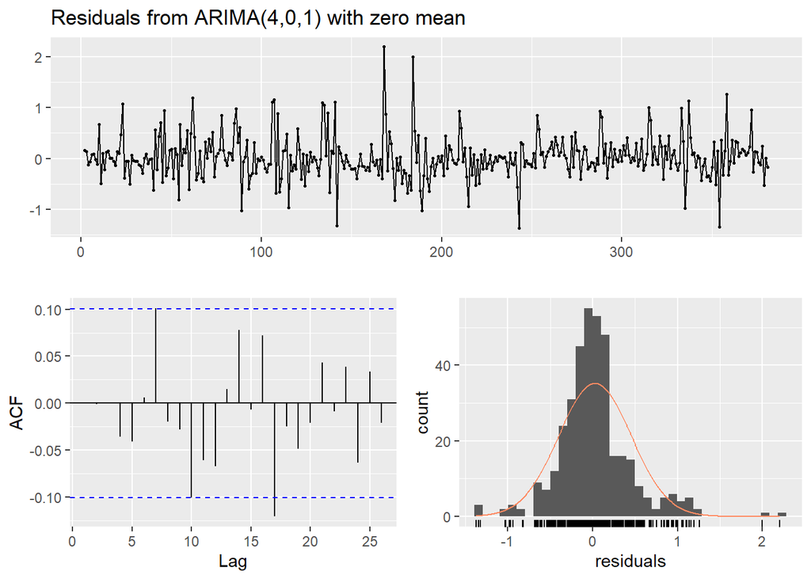

```
##
##  Ljung-Box test
##
## data:  Residuals from ARIMA(4,0,1) with zero mean
## Q* = 9.5777, df = 5, p-value = 0.08813
##
## Model df: 5.   Total lags used: 10
```

```r
checkresiduals(model_8$model)
```

```r
fcst[1,8] = round(exp(model_8$forecast[2]+
                    model_8$forecast[1]+
                    data_8[.N,c(log_sold_count)]),
                0)
```

Regarding the available information, the model seems to be adequate in terms of its residuals.

### Product 9

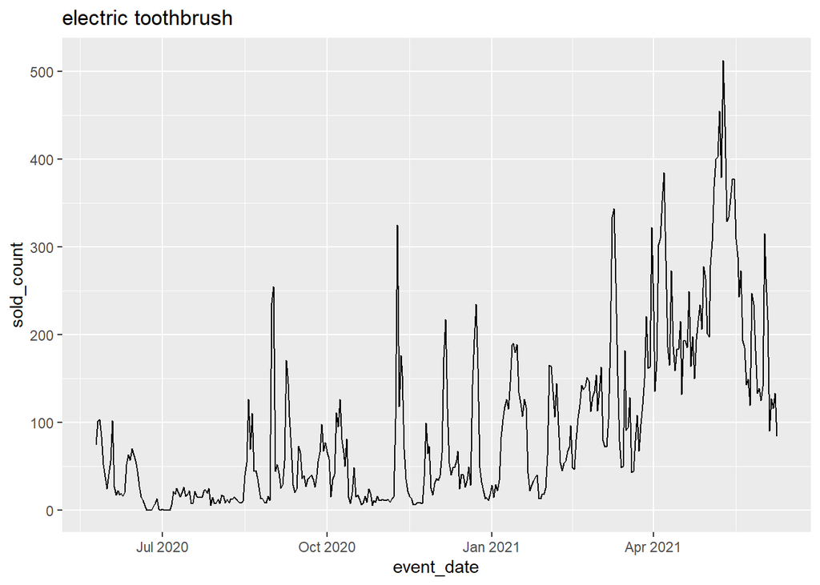

```r
ggplot(data_9, aes(x=event_date, y=sold_count)) + geom_line() + labs(title = "electric toothbrush")
```

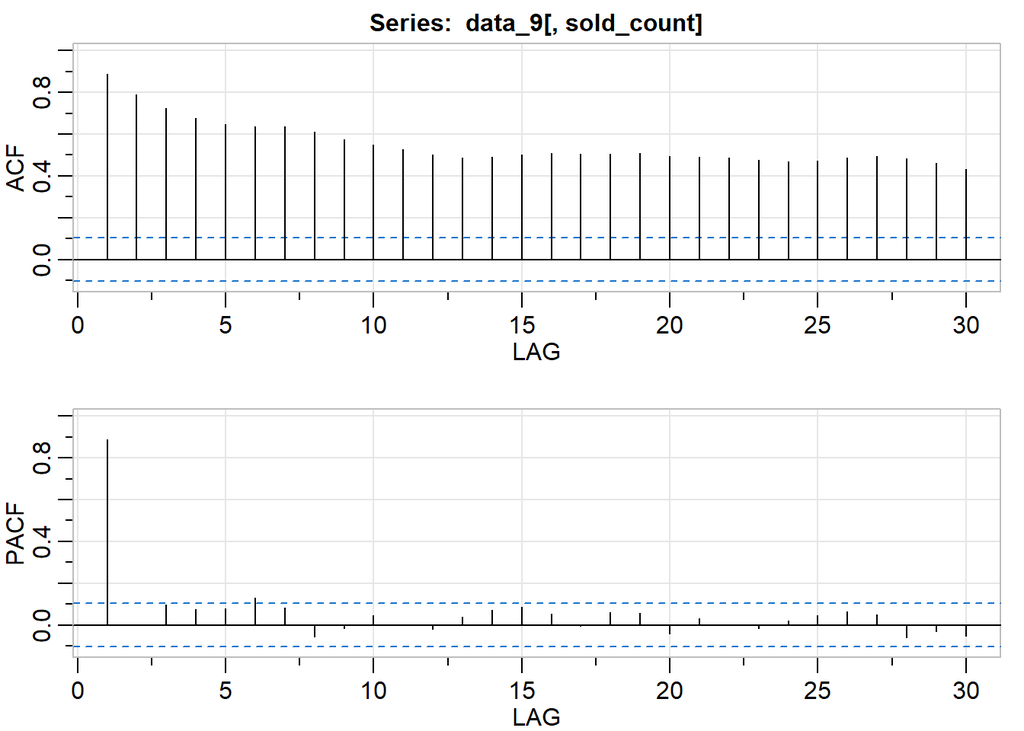

```
##      [,1] [,2] [,3] [,4] [,5] [,6] [,7]  [,8]  [,9] [,10] [,11] [,12] [,13]
## ACF  0.89 0.79 0.72 0.68 0.65 0.64 0.64  0.61  0.57  0.55  0.53  0.50  0.49
## PACF 0.89 0.00 0.10 0.07 0.08 0.13 0.08 -0.06 -0.02  0.05  0.00 -0.02  0.04
##      [,14] [,15] [,16] [,17] [,18] [,19] [,20] [,21] [,22] [,23] [,24] [,25]
## ACF   0.49  0.50  0.51  0.51  0.51  0.51  0.50  0.49  0.49  0.48  0.47  0.47
## PACF  0.07  0.09  0.05  0.00  0.06  0.06 -0.04  0.03  0.00 -0.02  0.02  0.05
##      [,26] [,27] [,28] [,29] [,30]
## ACF   0.49  0.50  0.48  0.46  0.43
## PACF  0.07  0.05 -0.06 -0.03 -0.05
```

```r
acf2(data_9[,sold_count])
```

There is not seasonality effect. It may be transformed using Box-Cox transformation.

```r
BoxCox.lambda(data_9[,sold_count], lower=0)
```

```
## [1] 0.1694096
```

It is not that close to zero, so the following transformation is appropriate.

```r
lambda_9 = BoxCox.lambda(data_9[,sold_count], lower=0)
data_9[,bc_sold_count:=BoxCox(sold_count, lambda = lambda_9)]
summary(ur.kpss(data_9[,bc_sold_count]))
```

```
##
## #######################
## # KPSS Unit Root Test #
## #######################
##
## Test is of type: mu with 5 lags.
##
## Value of test-statistic is: 3.5859
##
## Critical value for a significance level of:
##                 10pct  5pct 2.5pct  1pct
## critical values 0.347 0.463  0.574 0.739
```

The data does not seem to be stationary as the unit root test suggests.

```r
data_9[,lag_bc_sold_count:=shift(bc_sold_count,1)]
data_9[,dbc_sold_count:=bc_sold_count-lag_bc_sold_count]
summary(ur.kpss(data_9[,dbc_sold_count]))
```

```
##
## #######################
## # KPSS Unit Root Test #
## #######################
##
## Test is of type: mu with 5 lags.
##
## Value of test-statistic is: 0.0185
##
## Critical value for a significance level of:
##                 10pct  5pct 2.5pct  1pct
## critical values 0.347 0.463  0.574 0.739
```

Now, stationarity can be assumed. At this point, a linear model can be fitted to the series. In order to use `basket_count`, it should be differenced as well. Also note the use of lagged differenced `basket_count`, since forecast for 2 periods ahead is needed.

```r
data_9[,lag_basket_count:=shift(basket_count,1)]
data_9[,diff_basket_count:=basket_count-lag_basket_count]
data_9[,lag2_basket_count:=shift(basket_count,2)]
data_9[,lag2_diff_basket_count:=shift(diff_basket_count,2)]
lm_9_1 = lm(dbc_sold_count~lag2_diff_basket_count+special+as.factor(wday), data_9)
anova(lm_9_1)
```

```
## Analysis of Variance Table
##
## Response: dbc_sold_count
##                         Df Sum Sq Mean Sq F value Pr(>F)
## lag2_diff_basket_count   1   2.46 2.45754  1.3500 0.2460
## special                  1   0.02 0.02397  0.0132 0.9087
## as.factor(wday)          6  11.52 1.91927  1.0543 0.3898
## Residuals              369 671.72 1.82039
```

None of these variables are important.

Now, as the second modeling strategy, the original series is tried to be modeled linearly.

```r
lm_9_2 = lm(sold_count~as.factor(special)+as.factor(wday)+lag2_basket_count, data_9)
anova(lm_9_2)
```

```
## Analysis of Variance Table
##
## Response: sold_count
##                     Df  Sum Sq Mean Sq  F value  Pr(>F)
## as.factor(special)   1     528     528   0.1487 0.70003
## as.factor(wday)      6   44282    7380   2.0788 0.05493 .
## lag2_basket_count    1 2325278 2325278 654.9665 < 2e-16 ***
## Residuals          370 1313583    3550
## ---
## Signif. codes:  0 '***' 0.001 '**' 0.01 '*' 0.05 '.' 0.1 ' ' 1
```

If only the important variables to be used,

```r
lm_9_2 = lm(sold_count~lag2_basket_count, data_9)
summary(lm_9_2)
```

```
##
## Call:
## lm(formula = sold_count ~ lag2_basket_count, data = data_9)
##
## Residuals:
##     Min      1Q  Median      3Q     Max
## -210.08  -25.82  -14.94   17.15  286.21
##
## Coefficients:
##                    Estimate Std. Error t value Pr(>|t|)
## (Intercept)       20.339329   4.306273   4.723 3.28e-06 ***
## lag2_basket_count  0.184468   0.007421  24.857  < 2e-16 ***
## ---
## Signif. codes:  0 '***' 0.001 '**' 0.01 '*' 0.05 '.' 0.1 ' ' 1
##
## Residual standard error: 60.85 on 377 degrees of freedom
##   (2 observations deleted due to missingness)
## Multiple R-squared:  0.6211, Adjusted R-squared:   0.62
## F-statistic: 617.9 on 1 and 377 DF,  p-value: < 2.2e-16
```

```r
data_9[,res:=c(rep(NA,2),residuals(lm_9_2))]
summary(ur.kpss(data_9[,res]))
```

```
##
## #######################
## # KPSS Unit Root Test #
## #######################
##
## Test is of type: mu with 5 lags.
##
## Value of test-statistic is: 1.0891
##
## Critical value for a significance level of:
##                 10pct  5pct 2.5pct  1pct
## critical values 0.347 0.463  0.574 0.739
```

Large test statistic suggests that differencing is required for stationarity.

```r
data_9[,lag_res:=shift(res,1)]
data_9[,d_res:=res-lag_res]
summary(ur.kpss(data_9[,d_res]))
```

```
##
## #######################
## # KPSS Unit Root Test #
## #######################
##
## Test is of type: mu with 5 lags.
##
## Value of test-statistic is: 0.0102
##
## Critical value for a significance level of:
##                 10pct  5pct 2.5pct  1pct
## critical values 0.347 0.463  0.574 0.739
```

In order to compare the models,

```r
results=vector('list',length(test_dates))
for(i in 1:length(test_dates)){
  current_date=test_dates[i]-forecast_ahead

  past_data=data_9[event_date<=current_date]
  forecast_data=data_9[event_date==test_dates[i]]

  # arima model
  frcst=forecast_with_arima(past_data, forecast_ahead, target_name = "dbc_sold_count", is_trace = F)
  forecast_data[,arima_prediction:=round(InvBoxCox(frcst$forecast[2]+
                                                   frcst$forecast[1]+
                                                   past_data[.N,c(bc_sold_count)],
                                                   lambda = lambda_9),
                                         0)]

  # arimax model (special)(not exactly arimax)
  frcst=forecast_with_arima(past_data, forecast_ahead, target_name = "d_res", is_trace = F)
  reg = data.frame(lag2_basket_count=past_data[.N,lag2_basket_count])
  forecast_data[,arimax_prediction:=round(frcst$forecast[2]+
                                          frcst$forecast[1]+
                                          predict(lm_9_2,reg)+
                                          past_data[.N,res],
                                          0)]

  results[[i]]=forecast_data
}
overall_results=rbindlist(results)
melted_result_9=melt(overall_results,c('event_date','sold_count'),
                     c('arima_prediction','arimax_prediction'))
performance_9= melted_result_9[,accu(sold_count,value),by=list(variable)]
performance_9
```

```
##             variable  n     mean       sd        CV      FBias      MAPE
## 1:  arima_prediction 21 171.9048 64.24633 0.3737321 -0.2360111 0.4990322
## 2: arimax_prediction 21 171.9048 64.24633 0.3737321 -0.1360111 0.4489105
##        RMSE      MAD      MADP     WMAPE
## 1: 85.95791 75.04762 0.4365651 0.4365651
## 2: 79.00964 68.61905 0.3991690 0.3991690
```

The second model is better.

```r
model_9=forecast_with_arima(data_9,forecast_ahead = 2, target_name = "d_res")
```

```
##
##  ARIMA(0,0,0) with zero mean     : 4191.314
##  ARIMA(0,0,0) with non-zero mean : 4193.334
##  ARIMA(0,0,1) with zero mean     : 4171.034
##  ARIMA(0,0,1) with non-zero mean : Inf
##  ARIMA(0,0,2) with zero mean     : 4020.873
##  ARIMA(0,0,2) with non-zero mean : Inf
##  ARIMA(0,0,3) with zero mean     : 4022.916
##  ARIMA(0,0,3) with non-zero mean : Inf
##  ARIMA(0,0,4) with zero mean     : 4024.481
##  ARIMA(0,0,4) with non-zero mean : Inf
##  ARIMA(0,0,5) with zero mean     : 4025.086
##  ARIMA(0,0,5) with non-zero mean : Inf
##  ARIMA(1,0,0) with zero mean     : 4193.14
##  ARIMA(1,0,0) with non-zero mean : 4195.17
##  ARIMA(1,0,1) with zero mean     : 4085.201
##  ARIMA(1,0,1) with non-zero mean : Inf
##  ARIMA(1,0,2) with zero mean     : 4022.916
##  ARIMA(1,0,2) with non-zero mean : Inf
##  ARIMA(1,0,3) with zero mean     : Inf
##  ARIMA(1,0,3) with non-zero mean : Inf
##  ARIMA(1,0,4) with zero mean     : 4025.449
##  ARIMA(1,0,4) with non-zero mean : Inf
##  ARIMA(2,0,0) with zero mean     : 4115.524
##  ARIMA(2,0,0) with non-zero mean : 4117.567
##  ARIMA(2,0,1) with zero mean     : 4041.598
##  ARIMA(2,0,1) with non-zero mean : Inf
##  ARIMA(2,0,2) with zero mean     : 4024.504
##  ARIMA(2,0,2) with non-zero mean : Inf
##  ARIMA(2,0,3) with zero mean     : Inf
##  ARIMA(2,0,3) with non-zero mean : Inf
##  ARIMA(3,0,0) with zero mean     : 4114.438
##  ARIMA(3,0,0) with non-zero mean : 4116.492
##  ARIMA(3,0,1) with zero mean     : 4037.574
##  ARIMA(3,0,1) with non-zero mean : Inf
##  ARIMA(3,0,2) with zero mean     : 4025.209
##  ARIMA(3,0,2) with non-zero mean : Inf
##  ARIMA(4,0,0) with zero mean     : 4080.222
##  ARIMA(4,0,0) with non-zero mean : 4082.286
##  ARIMA(4,0,1) with zero mean     : 4029.79
##  ARIMA(4,0,1) with non-zero mean : Inf
##  ARIMA(5,0,0) with zero mean     : 4073.259
##  ARIMA(5,0,0) with non-zero mean : 4075.334
##
##
##
##  Best model: ARIMA(0,0,2) with zero mean
```

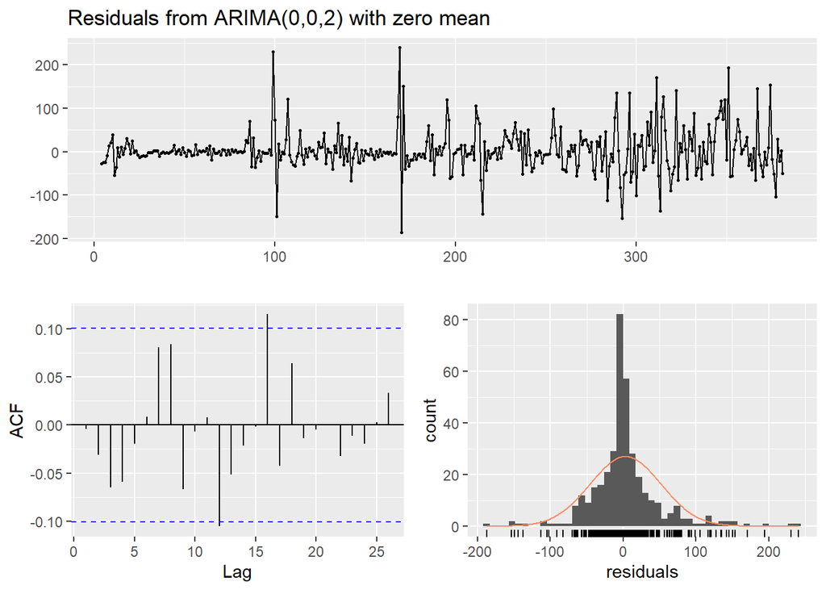

```
##
##  Ljung-Box test
##
## data:  Residuals from ARIMA(0,0,2) with zero mean
## Q* = 10.518, df = 8, p-value = 0.2305
##
## Model df: 2.   Total lags used: 10
```

```r
checkresiduals(model_9$model)
```

```r
reg = data.frame(lag2_basket_count=data_9[.N,lag2_basket_count])
fcst[1,9] = round(model_9$forecast[2]+
                model_9$forecast[1]+
                predict(lm_9_2,reg)+
                data_9[.N,c(res)],
                0)
```

Regarding the available information, the model seems to be adequate in terms of its residuals.

## Regarding the Forecasts

At the end forecasts are as follows:

```r
predictions=unique(data[,list(product_content_id)])
for(i in 1:9){
  predictions[product_content_id==fcst[2,i],forecast:=fcst[1,i]]
}
```

```r
print(predictions)
```

```
##    product_content_id forecast
## 1:              85004       83
## 2:            4066298      315
## 3:            6676673      449
## 4:            7061886       22
## 5:           31515569      460
## 6:           32737302       44
## 7:           32939029      131
## 8:           48740784        2
## 9:           73318567       76
```

## Conclusion

In this project, number of sales of several products which are sold on Trendyol are tried to be forecasted with time series forecasting methods. Effects of seasonality is not observed in the number of sales. Some products were not stationary, thus a differencing is made to make the number of sales of those products stationary. Generally, WMAPE is used as a metric to compare the models. For some products ARIMA model yields a lower WMAPE value. On the other hand, ARIMAX models is better for the remaining products. If the number of sales is modeled with ARIMAX models, lagged `wday`, `special`, and `basket_count` variables are used and in some cases, their differenced versions are used.

## Appendix

For some of the models, it may be confusing to understand how predictions are made. The following equations explain some of them.

#### First Model

Let *A* be the prediction provided by ARIMA.

ARIMA on dl_$Y_{t}$ (differenced and logged)

$log\hat{Y}_{t+2}-log\hat{Y}_{t+1}= A_{t+2}$

$log\hat{Y}_{t+1}-log{Y}_{t}= A_{t+1}$

Combining them

$log\hat{Y}_{t+2}= A_{t+1}+A_{t+2}+log{Y}_{t}$

$\hat{Y}_{t+2}=e^{ (A_{t+1}+A_{t+2}+log{Y}_{t})}$

#### Second Model

$log\hat{Y}_{t+2}-log\hat{Y}_{t+1}=f(X_{t+2})+\hatε_{t+2}$

$log\hat{Y}_{t+1}-log\hat{Y}_{t}=f(X_{t+1})+\hatε_{t+1}$

$log\hat{Y}_{t+2}=f(X_{t+2})+f(X_{t+1})+\hatε_{t+2}+\hatε_{t+1}+log{Y}_{t}$

where $f$ is the prediction provided by linear model.

$\hatε_{t+2}=A_{t+2}$ and $\hatε_{t+1}=A_{t+1}$

Thus,

$\hat{Y}_{t+2}=e^{(f(X_{t+2})+f(X_{t+1})+A_{t+2}+A_{t+1}+log{Y}_{t})}$

#### Last Model

$\hat{Y}_{t+2}=f(X_{t+2})+\hatε_{t+2}$

$\hatε_{t+2}=A_{t+2}$

$\hat{Y}_{t+2}=f(X_{t+2})+A_{t+2}$